# aly6980_MundreJaya_eda

```python
# Step 1: Import required libraries
import pandas as pd
import matplotlib.pyplot as plt
import zipfile
import os
from google.colab import drive
```

```python
import shutil

extract_folder = '/content/extracted_pde_files'

# Delete the folder and all its contents
shutil.rmtree(extract_folder, ignore_errors=True)

# Confirm deletion
print(f"Deleted folder: {extract_folder}")
```

```
Deleted folder: /content/extracted_pde_files
```

```python
# Step 2: Mount Google Drive
drive.mount('/content/drive')
```

```python
import os
import zipfile

# List of ZIP file paths from Google Drive
uploaded_files = [
    '/content/drive/MyDrive/ALY_6980_Zip_files/DE1_0_2008_to_2010_Prescription_Drug_Events_Sample_1.zip',
    '/content/drive/MyDrive/ALY_6980_Zip_files/DE1_0_2008_to_2010_Prescription_Drug_Events_Sample_2.zip',
    '/content/drive/MyDrive/ALY_6980_Zip_files/DE1_0_2008_to_2010_Prescription_Drug_Events_Sample_3.zip',
    '/content/drive/MyDrive/ALY_6980_Zip_files/DE1_0_2008_to_2010_Prescription_Drug_Events_Sample_4.zip',
    '/content/drive/MyDrive/ALY_6980_Zip_files/DE1_0_2008_to_2010_Prescription_Drug_Events_Sample_5.zip',
    '/content/drive/MyDrive/ALY_6980_Zip_files/DE1_0_2008_to_2010_Prescription_Drug_Events_Sample_6.zip',
    '/content/drive/MyDrive/ALY_6980_Zip_files/DE1_0_2008_to_2010_Prescription_Drug_Events_Sample_7.zip',
    '/content/drive/MyDrive/ALY_6980_Zip_files/DE1_0_2008_to_2010_Prescription_Drug_Events_Sample_8.zip',
    '/content/drive/MyDrive/ALY_6980_Zip_files/DE1_0_2008_to_2010_Prescription_Drug_Events_Sample_9.zip',
    '/content/drive/MyDrive/ALY_6980_Zip_files/DE1_0_2008_to_2010_Prescription_Drug_Events_Sample_10.zip',
    '/content/drive/MyDrive/ALY_6980_Zip_files/DE1_0_2008_to_2010_Prescription_Drug_Events_Sample_11.zip',
    '/content/drive/MyDrive/ALY_6980_Zip_files/DE1_0_2008_to_2010_Prescription_Drug_Events_Sample_12.zip',
    '/content/drive/MyDrive/ALY_6980_Zip_files/DE1_0_2008_to_2010_Prescription_Drug_Events_Sample_13.zip',
    '/content/drive/MyDrive/ALY_6980_Zip_files/DE1_0_2008_to_2010_Prescription_Drug_Events_Sample_14.zip',
    '/content/drive/MyDrive/ALY_6980_Zip_files/DE1_0_2008_to_2010_Prescription_Drug_Events_Sample_15.zip',
    '/content/drive/MyDrive/ALY_6980_Zip_files/176528_DE1_0_2008_to_2010_Outpatient_Claims_Sample_17.zip',
    '/content/drive/MyDrive/ALY_6980_Zip_files/176529_DE1_0_2008_to_2010_Outpatient_Claims_Sample_16.zip',
    '/content/drive/MyDrive/ALY_6980_Zip_files/176531_DE1_0_2008_to_2010_Outpatient_Claims_Sample_11.zip',
    '/content/drive/MyDrive/ALY_6980_Zip_files/176542_DE1_0_2008_to_2010_Outpatient_Claims_Sample_2.zip',
    '/content/drive/MyDrive/ALY_6980_Zip_files/176553_DE1_0_2008_to_2010_Outpatient_Claims_Sample_14.zip',
    '/content/drive/MyDrive/ALY_6980_Zip_files/176624_DE1_0_2008_to_2010_Outpatient_Claims_Sample_9.zip',
    '/content/drive/MyDrive/ALY_6980_Zip_files/176622_DE1_0_2008_to_2010_Outpatient_Claims_Sample_6.zip',
    '/content/drive/MyDrive/ALY_6980_Zip_files/176616_DE1_0_2008_to_2010_Outpatient_Claims_Sample_1.zip',
    '/content/drive/MyDrive/ALY_6980_Zip_files/176605_DE1_0_2008_to_2010_Outpatient_Claims_Sample_7.zip',
    '/content/drive/MyDrive/ALY_6980_Zip_files/176554_DE1_0_2008_to_2010_Outpatient_Claims_Sample_8.zip',
    '/content/drive/MyDrive/ALY_6980_Zip_files/176556_DE1_0_2008_to_2010_Outpatient_Claims_Sample_4.zip',
    '/content/drive/MyDrive/ALY_6980_Zip_files/176565_DE1_0_2008_to_2010_Outpatient_Claims_Sample_5.zip',
    '/content/drive/MyDrive/ALY_6980_Zip_files/176568_DE1_0_2008_to_2010_Outpatient_Claims_Sample_12.zip',
    '/content/drive/MyDrive/ALY_6980_Zip_files/176569_DE1_0_2008_to_2010_Outpatient_Claims_Sample_3.zip',
    '/content/drive/MyDrive/ALY_6980_Zip_files/176575_DE1_0_2008_to_2010_Outpatient_Claims_Sample_10.zip',
    '/content/drive/MyDrive/ALY_6980_Zip_files/176560_DE1_0_2008_to_2010_Inpatient_Claims_Sample_3.zip',
    '/content/drive/MyDrive/ALY_6980_Zip_files/176627_DE1_0_2008_to_2010_Inpatient_Claims_Sample_6.zip',
    '/content/drive/MyDrive/ALY_6980_Zip_files/176536_DE1_0_2008_to_2010_Inpatient_Claims_Sample_9.zip',
    '/content/drive/MyDrive/ALY_6980_Zip_files/176610_DE1_0_2008_to_2010_Inpatient_Claims_Sample_2.zip',
    '/content/drive/MyDrive/ALY_6980_Zip_files/176606_DE1_0_2008_to_2010_Inpatient_Claims_Sample_10.zip',
    '/content/drive/MyDrive/ALY_6980_Zip_files/176596_DE1_0_2008_to_2010_Inpatient_Claims_Sample_13.zip',
    '/content/drive/MyDrive/ALY_6980_Zip_files/176590_DE1_0_2008_to_2010_Inpatient_Claims_Sample_4.zip',
    '/content/drive/MyDrive/ALY_6980_Zip_files/176583_DE1_0_2008_to_2010_Inpatient_Claims_Sample_8.zip',
    '/content/drive/MyDrive/ALY_6980_Zip_files/176555_DE1_0_2008_to_2010_Inpatient_Claims_Sample_12.zip',
    '/content/drive/MyDrive/ALY_6980_Zip_files/176533_DE1_0_2008_to_2010_Inpatient_Claims_Sample_14.zip',
    '/content/drive/MyDrive/ALY_6980_Zip_files/176604_DE1_0_2008_to_2010_Inpatient_Claims_Sample_19.zip',
    '/content/drive/MyDrive/ALY_6980_Zip_files/176602_DE1_0_2008_to_2010_Inpatient_Claims_Sample_16.zip',
    '/content/drive/MyDrive/ALY_6980_Zip_files/176596_DE1_0_2008_to_2010_Inpatient_Claims_Sample_13.zip',
    '/content/drive/MyDrive/ALY_6980_Zip_files/176585_DE1_0_2008_to_2010_Inpatient_Claims_Sample_11.zip',
    '/content/drive/MyDrive/ALY_6980_Zip_files/176578_DE1_0_2008_to_2010_Inpatient_Claims_Sample_15.zip',
    '/content/drive/MyDrive/ALY_6980_Zip_files/176577_DE1_0_2008_to_2010_Inpatient_Claims_Sample_5.zip',
    '/content/drive/MyDrive/ALY_6980_Zip_files/176545_DE1_0_2008_to_2010_Inpatient_Claims_Sample_18.zip'
]

# Folder to extract contents into
extract_folder = '/content/extracted_pde_files'
os.makedirs(extract_folder, exist_ok=True)

# Extract only valid ZIP files
for zip_path in uploaded_files:
    try:
        if zipfile.is_zipfile(zip_path):
            print(f"✅ Extracting: {os.path.basename(zip_path)}")
            with zipfile.ZipFile(zip_path, 'r') as zip_ref:
                zip_ref.extractall(extract_folder)
        else:
            print(f"❌ Skipped (Not a ZIP): {os.path.basename(zip_path)}")
    except zipfile.BadZipFile:
        print(f"❌ Corrupted ZIP: {os.path.basename(zip_path)}")

# List extracted files
extracted_files = os.listdir(extract_folder)
print(f"\nTotal files extracted: {len(extracted_files)}")
extracted_files[:10]  # Preview first 10 files
```

```
✅ Extracting: DE1_0_2008_to_2010_Prescription_Drug_Events_Sample_1.zip
✅ Extracting: DE1_0_2008_to_2010_Prescription_Drug_Events_Sample_2.zip
✅ Extracting: DE1_0_2008_to_2010_Prescription_Drug_Events_Sample_3.zip
✅ Extracting: DE1_0_2008_to_2010_Prescription_Drug_Events_Sample_4.zip
✅ Extracting: DE1_0_2008_to_2010_Prescription_Drug_Events_Sample_5.zip
✅ Extracting: DE1_0_2008_to_2010_Prescription_Drug_Events_Sample_6.zip
✅ Extracting: DE1_0_2008_to_2010_Prescription_Drug_Events_Sample_7.zip
✅ Extracting: DE1_0_2008_to_2010_Prescription_Drug_Events_Sample_8.zip
✅ Extracting: DE1_0_2008_to_2010_Prescription_Drug_Events_Sample_9.zip
✅ Extracting: DE1_0_2008_to_2010_Prescription_Drug_Events_Sample_10.zip
✅ Extracting: DE1_0_2008_to_2010_Prescription_Drug_Events_Sample_11.zip
✅ Extracting: DE1_0_2008_to_2010_Prescription_Drug_Events_Sample_12.zip
✅ Extracting: DE1_0_2008_to_2010_Prescription_Drug_Events_Sample_13.zip
✅ Extracting: DE1_0_2008_to_2010_Prescription_Drug_Events_Sample_14.zip
✅ Extracting: DE1_0_2008_to_2010_Prescription_Drug_Events_Sample_15.zip
✅ Extracting: 176528_DE1_0_2008_to_2010_Outpatient_Claims_Sample_17.zip
✅ Extracting: 176529_DE1_0_2008_to_2010_Outpatient_Claims_Sample_16.zip
✅ Extracting: 176531_DE1_0_2008_to_2010_Outpatient_Claims_Sample_11.zip
✅ Extracting: 176542_DE1_0_2008_to_2010_Outpatient_Claims_Sample_2.zip
✅ Extracting: 176553_DE1_0_2008_to_2010_Outpatient_Claims_Sample_14.zip
✅ Extracting: 176624_DE1_0_2008_to_2010_Outpatient_Claims_Sample_9.zip
✅ Extracting: 176622_DE1_0_2008_to_2010_Outpatient_Claims_Sample_6.zip
✅ Extracting: 176616_DE1_0_2008_to_2010_Outpatient_Claims_Sample_1.zip
✅ Extracting: 176605_DE1_0_2008_to_2010_Outpatient_Claims_Sample_7.zip
✅ Extracting: 176554_DE1_0_2008_to_2010_Outpatient_Claims_Sample_8.zip
✅ Extracting: 176556_DE1_0_2008_to_2010_Outpatient_Claims_Sample_4.zip
✅ Extracting: 176565_DE1_0_2008_to_2010_Outpatient_Claims_Sample_5.zip
✅ Extracting: 176568_DE1_0_2008_to_2010_Outpatient_Claims_Sample_12.zip
✅ Extracting: 176569_DE1_0_2008_to_2010_Outpatient_Claims_Sample_3.zip
✅ Extracting: 176575_DE1_0_2008_to_2010_Outpatient_Claims_Sample_10.zip
✅ Extracting: 176560_DE1_0_2008_to_2010_Inpatient_Claims_Sample_3.zip
✅ Extracting: 176627_DE1_0_2008_to_2010_Inpatient_Claims_Sample_6.zip
✅ Extracting: 176536_DE1_0_2008_to_2010_Inpatient_Claims_Sample_9.zip
✅ Extracting: 176610_DE1_0_2008_to_2010_Inpatient_Claims_Sample_2.zip
✅ Extracting: 176606_DE1_0_2008_to_2010_Inpatient_Claims_Sample_10.zip
✅ Extracting: 176596_DE1_0_2008_to_2010_Inpatient_Claims_Sample_13.zip
✅ Extracting: 176590_DE1_0_2008_to_2010_Inpatient_Claims_Sample_4.zip
✅ Extracting: 176583_DE1_0_2008_to_2010_Inpatient_Claims_Sample_8.zip
✅ Extracting: 176555_DE1_0_2008_to_2010_Inpatient_Claims_Sample_12.zip
✅ Extracting: 176533_DE1_0_2008_to_2010_Inpatient_Claims_Sample_14.zip
✅ Extracting: 176604_DE1_0_2008_to_2010_Inpatient_Claims_Sample_19.zip
✅ Extracting: 176602_DE1_0_2008_to_2010_Inpatient_Claims_Sample_16.zip
✅ Extracting: 176596_DE1_0_2008_to_2010_Inpatient_Claims_Sample_13.zip
✅ Extracting: 176585_DE1_0_2008_to_2010_Inpatient_Claims_Sample_11.zip
✅ Extracting: 176578_DE1_0_2008_to_2010_Inpatient_Claims_Sample_15.zip
✅ Extracting: 176577_DE1_0_2008_to_2010_Inpatient_Claims_Sample_5.zip
✅ Extracting: 176545_DE1_0_2008_to_2010_Inpatient_Claims_Sample_18.zip

Total files extracted: 47
```

```
['DE1_0_2008_to_2010_Prescription_Drug_Events_Sample_8.csv',
 'DE1_0_2008_to_2010_Inpatient_Claims_Sample_12.csv',
 'DE1_0_2008_to_2010_Inpatient_Claims_Sample_16.csv',
 'DE1_0_2008_to_2010_Outpatient_Claims_Sample_2.csv',
 'DE1_0_2008_to_2010_Prescription_Drug_Events_Sample_14.csv',
 'DE1_0_2008_to_2010_Prescription_Drug_Events_Sample_15.csv',
 'DE1_0_2008_to_2010_Prescription_Drug_Events_Sample_3.csv',
 'DE1_0_2008_to_2010_Prescription_Drug_Events_Sample_5.csv',
 'DE1_0_2008_to_2010_Prescription_Drug_Events_Sample_4.csv',
 'DE1_0_2008_to_2010_Inpatient_Claims_Sample_11.csv']
```

```python
# List all files in the extracted folder
csv_files = [os.path.join(extract_folder, f) for f in os.listdir(extract_folder) if f.endswith('.csv')]
print(f"Found {len(csv_files)} CSV files.")

for f in csv_files:
    print(f)
```

```
Found 46 CSV files.
/content/extracted_pde_files/DE1_0_2008_to_2010_Prescription_Drug_Events_Sample_8.csv
/content/extracted_pde_files/DE1_0_2008_to_2010_Inpatient_Claims_Sample_12.csv
/content/extracted_pde_files/DE1_0_2008_to_2010_Inpatient_Claims_Sample_16.csv
/content/extracted_pde_files/DE1_0_2008_to_2010_Outpatient_Claims_Sample_2.csv
/content/extracted_pde_files/DE1_0_2008_to_2010_Prescription_Drug_Events_Sample_14.csv
/content/extracted_pde_files/DE1_0_2008_to_2010_Prescription_Drug_Events_Sample_15.csv
/content/extracted_pde_files/DE1_0_2008_to_2010_Prescription_Drug_Events_Sample_3.csv
/content/extracted_pde_files/DE1_0_2008_to_2010_Prescription_Drug_Events_Sample_5.csv
/content/extracted_pde_files/DE1_0_2008_to_2010_Prescription_Drug_Events_Sample_4.csv
/content/extracted_pde_files/DE1_0_2008_to_2010_Inpatient_Claims_Sample_11.csv
/content/extracted_pde_files/DE1_0_2008_to_2010_Prescription_Drug_Events_Sample_6.csv
/content/extracted_pde_files/DE1_0_2008_to_2010_Outpatient_Claims_Sample_4.csv
/content/extracted_pde_files/DE1_0_2008_to_2010_Outpatient_Claims_Sample_16.csv
/content/extracted_pde_files/DE1_0_2008_to_2010_Outpatient_Claims_Sample_12.csv
/content/extracted_pde_files/DE1_0_2008_to_2010_Outpatient_Claims_Sample_14.csv
/content/extracted_pde_files/DE1_0_2008_to_2010_Outpatient_Claims_Sample_5.csv
/content/extracted_pde_files/DE1_0_2008_to_2010_Outpatient_Claims_Sample_10.csv
/content/extracted_pde_files/DE1_0_2008_to_2010_Inpatient_Claims_Sample_19.csv
/content/extracted_pde_files/DE1_0_2008_to_2010_Inpatient_Claims_Sample_14.csv
/content/extracted_pde_files/DE1_0_2008_to_2010_Outpatient_Claims_Sample_7.csv
/content/extracted_pde_files/DE1_0_2008_to_2010_Prescription_Drug_Events_Sample_12.csv
/content/extracted_pde_files/DE1_0_2008_to_2010_Prescription_Drug_Events_Sample_13.csv
/content/extracted_pde_files/DE1_0_2008_to_2010_Outpatient_Claims_Sample_1.csv
/content/extracted_pde_files/DE1_0_2008_to_2010_Outpatient_Claims_Sample_3.csv
/content/extracted_pde_files/DE1_0_2008_to_2010_Inpatient_Claims_Sample_4.csv
/content/extracted_pde_files/DE1_0_2008_to_2010_Inpatient_Claims_Sample_15.csv
/content/extracted_pde_files/DE1_0_2008_to_2010_Inpatient_Claims_Sample_8.csv
/content/extracted_pde_files/DE1_0_2008_to_2010_Prescription_Drug_Events_Sample_11.csv
/content/extracted_pde_files/DE1_0_2008_to_2010_Inpatient_Claims_Sample_5.csv
/content/extracted_pde_files/DE1_0_2008_to_2010_Prescription_Drug_Events_Sample_9.csv
/content/extracted_pde_files/DE1_0_2008_to_2010_Prescription_Drug_Events_Sample_7.csv
/content/extracted_pde_files/DE1_0_2008_to_2010_Inpatient_Claims_Sample_18.csv
/content/extracted_pde_files/DE1_0_2008_to_2010_Inpatient_Claims_Sample_13.csv
/content/extracted_pde_files/DE1_0_2008_to_2010_Inpatient_Claims_Sample_2.csv
/content/extracted_pde_files/DE1_0_2008_to_2010_Outpatient_Claims_Sample_11.csv
/content/extracted_pde_files/DE1_0_2008_to_2010_Outpatient_Claims_Sample_9.csv
/content/extracted_pde_files/DE1_0_2008_to_2010_Outpatient_Claims_Sample_17.csv
/content/extracted_pde_files/DE1_0_2008_to_2010_Prescription_Drug_Events_Sample_2.csv
/content/extracted_pde_files/DE1_0_2008_to_2010_Inpatient_Claims_Sample_3.csv
/content/extracted_pde_files/DE1_0_2008_to_2010_Inpatient_Claims_Sample_10.csv
/content/extracted_pde_files/DE1_0_2008_to_2010_Inpatient_Claims_Sample_6.csv
/content/extracted_pde_files/DE1_0_2008_to_2010_Outpatient_Claims_Sample_8.csv
/content/extracted_pde_files/DE1_0_2008_to_2010_Prescription_Drug_Events_Sample_1.csv
/content/extracted_pde_files/DE1_0_2008_to_2010_Prescription_Drug_Events_Sample_10.csv
/content/extracted_pde_files/DE1_0_2008_to_2010_Inpatient_Claims_Sample_9.csv
/content/extracted_pde_files/DE1_0_2008_to_2010_Outpatient_Claims_Sample_6.csv
```

# Description:

The extracted folder to identify and list all CSV files available for analysis. It ensures that:

Only files ending in .csv are selected (ignoring other file types).

Full file paths are constructed for each CSV, making them ready for reading or processing.

It confirms how many files were found and prints their names for verification.

This step is crucial for validating that your ZIP extraction worked correctly and that you're working with the expected input files.

```python
import pandas as pd
import glob
import os

# Optional: prettier table display
pd.set_option('display.max_columns', None)
pd.set_option('display.width', 120)

# Path to extracted CSV files
csv_files = glob.glob('/content/extracted_pde_files/*.csv')

print(f"Found {len(csv_files)} files in /content/extracted_pde_files")
```

```
Found 46 files in /content/extracted_pde_files
```

## Description:

To verify the availability and count of CSV files extracted from ZIPs and prepare them for loading into pandas for analysis.

```python
# # Load and concatenate all CSVs into one DataFrame
# pde_dataframes = []
# for file in csv_files:
#     try:
#         df = pd.read_csv(file, low_memory=False)
#         df['source_file'] = os.path.basename(file)  # Track origin
#         pde_dataframes.append(df)
#         print(f"Loaded: {os.path.basename(file)}")
#     except Exception as e:
#         print(f"Error reading {file}: {e}")
# print(f"Total dataframes loaded: {len(pde_dataframes)}")
```

```python
# Load and sample 30,000 rows from each CSV, then store in list
pde_dataframes = []

for file in csv_files:
    try:
        df = pd.read_csv(file, low_memory=False)

        # Sample up to 30,000 rows randomly
        df_sample = df.sample(n=min(100000, len(df)), random_state=42)
        df_sample['source_file'] = os.path.basename(file)  # Track file origin

        pde_dataframes.append(df_sample)
        print(f"✅ Sampled from: {os.path.basename(file)} | Rows: {len(df_sample)}")

    except Exception as e:
        print(f"❌ Error reading {file}: {e}")

print(f"\n📦 Total sampled dataframes: {len(pde_dataframes)}")
```

```
✅ Sampled from: DE1_0_2008_to_2010_Prescription_Drug_Events_Sample_8.csv | Rows: 100000
✅ Sampled from: DE1_0_2008_to_2010_Inpatient_Claims_Sample_12.csv | Rows: 66717
✅ Sampled from: DE1_0_2008_to_2010_Inpatient_Claims_Sample_16.csv | Rows: 66800
✅ Sampled from: DE1_0_2008_to_2010_Outpatient_Claims_Sample_2.csv | Rows: 100000
✅ Sampled from: DE1_0_2008_to_2010_Prescription_Drug_Events_Sample_14.csv | Rows: 100000
✅ Sampled from: DE1_0_2008_to_2010_Prescription_Drug_Events_Sample_15.csv | Rows: 100000
✅ Sampled from: DE1_0_2008_to_2010_Prescription_Drug_Events_Sample_3.csv | Rows: 100000
✅ Sampled from: DE1_0_2008_to_2010_Prescription_Drug_Events_Sample_5.csv | Rows: 100000
✅ Sampled from: DE1_0_2008_to_2010_Prescription_Drug_Events_Sample_4.csv | Rows: 100000
✅ Sampled from: DE1_0_2008_to_2010_Inpatient_Claims_Sample_11.csv | Rows: 66425
✅ Sampled from: DE1_0_2008_to_2010_Prescription_Drug_Events_Sample_6.csv | Rows: 100000
✅ Sampled from: DE1_0_2008_to_2010_Outpatient_Claims_Sample_4.csv | Rows: 100000
✅ Sampled from: DE1_0_2008_to_2010_Outpatient_Claims_Sample_16.csv | Rows: 100000
✅ Sampled from: DE1_0_2008_to_2010_Outpatient_Claims_Sample_12.csv | Rows: 100000
✅ Sampled from: DE1_0_2008_to_2010_Outpatient_Claims_Sample_14.csv | Rows: 100000
✅ Sampled from: DE1_0_2008_to_2010_Outpatient_Claims_Sample_5.csv | Rows: 100000
✅ Sampled from: DE1_0_2008_to_2010_Outpatient_Claims_Sample_10.csv | Rows: 100000
✅ Sampled from: DE1_0_2008_to_2010_Inpatient_Claims_Sample_19.csv | Rows: 67037
✅ Sampled from: DE1_0_2008_to_2010_Inpatient_Claims_Sample_14.csv | Rows: 67024
✅ Sampled from: DE1_0_2008_to_2010_Outpatient_Claims_Sample_7.csv | Rows: 100000
✅ Sampled from: DE1_0_2008_to_2010_Prescription_Drug_Events_Sample_12.csv | Rows: 100000
✅ Sampled from: DE1_0_2008_to_2010_Prescription_Drug_Events_Sample_13.csv | Rows: 100000
✅ Sampled from: DE1_0_2008_to_2010_Outpatient_Claims_Sample_1.csv | Rows: 100000
✅ Sampled from: DE1_0_2008_to_2010_Outpatient_Claims_Sample_3.csv | Rows: 100000
✅ Sampled from: DE1_0_2008_to_2010_Inpatient_Claims_Sample_4.csv | Rows: 66253
✅ Sampled from: DE1_0_2008_to_2010_Inpatient_Claims_Sample_15.csv | Rows: 66846
✅ Sampled from: DE1_0_2008_to_2010_Inpatient_Claims_Sample_8.csv | Rows: 66490
✅ Sampled from: DE1_0_2008_to_2010_Prescription_Drug_Events_Sample_11.csv | Rows: 100000
✅ Sampled from: DE1_0_2008_to_2010_Inpatient_Claims_Sample_5.csv | Rows: 66414
✅ Sampled from: DE1_0_2008_to_2010_Prescription_Drug_Events_Sample_9.csv | Rows: 100000
✅ Sampled from: DE1_0_2008_to_2010_Prescription_Drug_Events_Sample_7.csv | Rows: 100000
✅ Sampled from: DE1_0_2008_to_2010_Inpatient_Claims_Sample_18.csv | Rows: 66428
✅ Sampled from: DE1_0_2008_to_2010_Inpatient_Claims_Sample_13.csv | Rows: 66324
✅ Sampled from: DE1_0_2008_to_2010_Inpatient_Claims_Sample_2.csv | Rows: 66494
✅ Sampled from: DE1_0_2008_to_2010_Outpatient_Claims_Sample_11.csv | Rows: 100000
✅ Sampled from: DE1_0_2008_to_2010_Outpatient_Claims_Sample_9.csv | Rows: 100000
✅ Sampled from: DE1_0_2008_to_2010_Outpatient_Claims_Sample_17.csv | Rows: 100000
✅ Sampled from: DE1_0_2008_to_2010_Prescription_Drug_Events_Sample_2.csv | Rows: 100000
✅ Sampled from: DE1_0_2008_to_2010_Inpatient_Claims_Sample_3.csv | Rows: 66672
✅ Sampled from: DE1_0_2008_to_2010_Inpatient_Claims_Sample_10.csv | Rows: 66585
✅ Sampled from: DE1_0_2008_to_2010_Inpatient_Claims_Sample_6.csv | Rows: 66977
✅ Sampled from: DE1_0_2008_to_2010_Outpatient_Claims_Sample_8.csv | Rows: 100000
✅ Sampled from: DE1_0_2008_to_2010_Prescription_Drug_Events_Sample_1.csv | Rows: 100000
✅ Sampled from: DE1_0_2008_to_2010_Prescription_Drug_Events_Sample_10.csv | Rows: 100000
✅ Sampled from: DE1_0_2008_to_2010_Inpatient_Claims_Sample_9.csv | Rows: 66763
✅ Sampled from: DE1_0_2008_to_2010_Outpatient_Claims_Sample_6.csv | Rows: 100000

📦 Total sampled dataframes: 46
```

## Description:

The process involves loading multiple CSV files into memory while tracking their origins, handling any broken or unreadable files, and storing the successfully loaded DataFrames in a list for later consolidation.

```python
import pandas as pd
import glob
import os

# Get list of extracted CSV files
csv_files = glob.glob('/content/extracted_pde_files/*.csv')
print(f"📂 Found {len(csv_files)} files.")

# Output file path
output_path = "/content/pde_combined.csv"

# Remove the file if it already exists
if os.path.exists(output_path):
    os.remove(output_path)

# Initialize control variable
first_file = True

# Merge each file in chunks
for file in csv_files:
    try:
        print(f"📄 Processing {os.path.basename(file)} ...")
        for chunk in pd.read_csv(file, chunksize=100000, low_memory=True):
            chunk['source_file'] = os.path.basename(file)
            if first_file:
                chunk.to_csv(output_path, index=False, mode='w')  # Write header
                first_file = False
            else:
                chunk.to_csv(output_path, index=False, mode='a', header=False)  # Append
    except Exception as e:
        print(f"❌ Error processing {file}: {e}")

print(f"\n✅ All files merged and saved to: {output_path}")
```

```
📂 Found 46 files.
📄 Processing DE1_0_2008_to_2010_Prescription_Drug_Events_Sample_8.csv ...
```

```
📄 Processing DE1_0_2008_to_2010_Inpatient_Claims_Sample_12.csv ...
📄 Processing DE1_0_2008_to_2010_Inpatient_Claims_Sample_16.csv ...
📄 Processing DE1_0_2008_to_2010_Outpatient_Claims_Sample_2.csv ...
```

```
📄 Processing DE1_0_2008_to_2010_Prescription_Drug_Events_Sample_14.csv ...
```

```
📄 Processing DE1_0_2008_to_2010_Prescription_Drug_Events_Sample_15.csv ...
```

```
📄 Processing DE1_0_2008_to_2010_Prescription_Drug_Events_Sample_3.csv ...
```

```
📄 Processing DE1_0_2008_to_2010_Prescription_Drug_Events_Sample_5.csv ...
```

```
📄 Processing DE1_0_2008_to_2010_Prescription_Drug_Events_Sample_4.csv ...
```

```
📄 Processing DE1_0_2008_to_2010_Inpatient_Claims_Sample_11.csv ...
📄 Processing DE1_0_2008_to_2010_Prescription_Drug_Events_Sample_6.csv ...
```

```
📄 Processing DE1_0_2008_to_2010_Outpatient_Claims_Sample_4.csv ...
```

```
📄 Processing DE1_0_2008_to_2010_Outpatient_Claims_Sample_16.csv ...
```

```
📄 Processing DE1_0_2008_to_2010_Outpatient_Claims_Sample_12.csv ...
```

```
📄 Processing DE1_0_2008_to_2010_Outpatient_Claims_Sample_14.csv ...
```

```
📄 Processing DE1_0_2008_to_2010_Outpatient_Claims_Sample_5.csv ...
```

```
📄 Processing DE1_0_2008_to_2010_Outpatient_Claims_Sample_10.csv ...
```

```
📄 Processing DE1_0_2008_to_2010_Inpatient_Claims_Sample_19.csv ...
📄 Processing DE1_0_2008_to_2010_Inpatient_Claims_Sample_14.csv ...
📄 Processing DE1_0_2008_to_2010_Outpatient_Claims_Sample_7.csv ...
```

```
📄 Processing DE1_0_2008_to_2010_Prescription_Drug_Events_Sample_12.csv ...
```

```
📄 Processing DE1_0_2008_to_2010_Prescription_Drug_Events_Sample_13.csv ...
```

```
📄 Processing DE1_0_2008_to_2010_Outpatient_Claims_Sample_1.csv ...
```

```
📄 Processing DE1_0_2008_to_2010_Outpatient_Claims_Sample_3.csv ...
```

```
📄 Processing DE1_0_2008_to_2010_Inpatient_Claims_Sample_4.csv ...
📄 Processing DE1_0_2008_to_2010_Inpatient_Claims_Sample_15.csv ...
📄 Processing DE1_0_2008_to_2010_Inpatient_Claims_Sample_8.csv ...
📄 Processing DE1_0_2008_to_2010_Prescription_Drug_Events_Sample_11.csv ...
```

```
📄 Processing DE1_0_2008_to_2010_Inpatient_Claims_Sample_5.csv ...
📄 Processing DE1_0_2008_to_2010_Prescription_Drug_Events_Sample_9.csv ...
```

[output not shown]

```
📄 Processing DE1_0_2008_to_2010_Prescription_Drug_Events_Sample_7.csv ...
```

```
📄 Processing DE1_0_2008_to_2010_Inpatient_Claims_Sample_18.csv ...
📄 Processing DE1_0_2008_to_2010_Inpatient_Claims_Sample_13.csv ...
📄 Processing DE1_0_2008_to_2010_Inpatient_Claims_Sample_2.csv ...
📄 Processing DE1_0_2008_to_2010_Outpatient_Claims_Sample_11.csv ...
```

```
📄 Processing DE1_0_2008_to_2010_Outpatient_Claims_Sample_9.csv ...
```

```
📄 Processing DE1_0_2008_to_2010_Outpatient_Claims_Sample_17.csv ...
```

```
📄 Processing DE1_0_2008_to_2010_Prescription_Drug_Events_Sample_2.csv ...
```

```
📄 Processing DE1_0_2008_to_2010_Inpatient_Claims_Sample_3.csv ...
📄 Processing DE1_0_2008_to_2010_Inpatient_Claims_Sample_10.csv ...
📄 Processing DE1_0_2008_to_2010_Inpatient_Claims_Sample_6.csv ...
📄 Processing DE1_0_2008_to_2010_Outpatient_Claims_Sample_8.csv ...
```

```
📄 Processing DE1_0_2008_to_2010_Prescription_Drug_Events_Sample_1.csv ...
```

```
📄 Processing DE1_0_2008_to_2010_Prescription_Drug_Events_Sample_10.csv ...
```

```
📄 Processing DE1_0_2008_to_2010_Inpatient_Claims_Sample_9.csv ...
📄 Processing DE1_0_2008_to_2010_Outpatient_Claims_Sample_6.csv ...
```

```
✅ All files merged and saved to: /content/pde_combined.csv
```

```python
!pip install fastparquet
```

```
Downloading fastparquet-2024.11.0-cp311-cp311-manylinux_2_17_x86_64.manylinux2014_x86_64.whl (1.8 MB)
   ━━━━━━━━━━━━━━━━━━━━━━━━━━━━━━━━━━━━━━━━ 1.8/1.8 MB 19.9 MB/s eta 0:00:00
Downloading cramjam-2.10.0-cp311-cp311-manylinux_2_17_x86_64.manylinux2014_x86_64.whl (2.0 MB)
   ━━━━━━━━━━━━━━━━━━━━━━━━━━━━━━━━━━━━━━━━ 2.0/2.0 MB 74.1 MB/s eta 0:00:00
```

## Description:

This code efficiently converts a large CSV file (pde_combined.csv) into a compressed Parquet file by processing it in memory-friendly chunks and correctly formatting the PROD_SRVC_ID column.

```python
# import pandas as pd

# chunks = pd.read_csv("/content/drive/MyDrive/pde_combined.csv", chunksize=100_000, low_memory=False)

# for i, chunk in enumerate(chunks):
#     if 'PROD_SRVC_ID' in chunk.columns:
#         chunk['PROD_SRVC_ID'] = chunk['PROD_SRVC_ID'].astype(str)

#     # ✅ Save chunk
#     chunk.to_parquet("/content/pde_combined.parquet",
#                      engine='fastparquet',
#                      compression='gzip',
#                      index=False,
#                      append=(i > 0))
#     print(f"✅ Saved chunk {i+1}")
```

### Description:

```python
# import pandas as pd
# import numpy as np
# import random

# # First, count total number of lines in the file
# file_path = "/content/pde_combined.csv"
# with open(file_path, 'r') as f:
#     total_lines = sum(1 for line in f)

# # Exclude header
# n_data_lines = total_lines - 1

# # Calculate how many lines to skip (i.e., 50% of rows)
# n_skip = int(n_data_lines * 0.3)

# # Randomly choose lines to skip (excluding header row index 0)
# skip_indices = sorted(random.sample(range(1, total_lines), n_skip))

# # Read the file, skipping 50% of rows
# df_sample = pd.read_csv(file_path, skiprows=skip_indices, low_memory=False)

# print(f"✅ Sample shape: {df_sample.shape}")
# df_sample.head()
```

```python
import pandas as pd

# Combine the sampled DataFrames
combined_df = pd.concat(pde_dataframes, ignore_index=True)
print(f"✅ Combined shape: {combined_df.shape}")

# Define path to save in Google Drive
parquet_path = '/content/drive/MyDrive/pde_combined.parquet'

# Save as Parquet
combined_df.to_parquet(parquet_path, index=False)
print(f"💾 Parquet file saved to: {parquet_path}")
```

```
✅ Combined shape: (4066249, 91)
💾 Parquet file saved to: /content/drive/MyDrive/pde_combined.parquet
```

### Description:

I’ve merged all chunks into one DataFrame with 4,066,249 rows and 91 columns, then saved it as a Parquet file for efficient, columnar storage.

```python
# Save to a mini parquet file
df_sample.to_parquet("/content/drive/MyDrive/pde_sample.parquet", compression='gzip', engine='fastparquet')
print("✅ Sample saved to /content/drive/MyDrive/pde_sample.parquet")
```

```
✅ Sample saved to /content/drive/MyDrive/pde_sample.parquet
```

```python
# Load the small sample from Parquet
df_sample = pd.read_parquet("/content/drive/MyDrive/pde_combined.parquet", engine='fastparquet')
print(f"✅ Loaded sample: {df_sample.shape}")
df_sample.head()
```

```
✅ Loaded sample: (4066249, 91)
```

|  | DESYNPUF_ID | PDE_ID | SRVC_DT | PROD_SRVC_ID | QTY_DSPNSD_NUM | DAYS_SUPLY_NUM | PTNT_PAY_AMT | TOT_RX_CST_AMT | source_file | CLM_ID | SEGMENT | CLM_FROM_DT | CLM_THRU_DT | PRVDR_NUM | CLM_PMT_AMT | NCH_PRMRY_PYR_CLM_PD_AMT | AT_PHYSN_NPI | OP_PHYSN_NPI | OT_PHYSN_NPI | CLM_ADMSN_DT | ADMTNG_ICD9_DGNS_CD | CLM_PASS_THRU_PER_DIEM_AMT | NCH_BENE_IP_DDCTBL_AMT | NCH_BENE_PTA_COINSRNC_LBLTY_AM | NCH_BENE_BLOOD_DDCTBL_LBLTY_AM | CLM_UTLZTN_DAY_CNT | NCH_BENE_DSCHRG_DT | CLM_DRG_CD | ICD9_DGNS_CD_1 | … |
| --- | --- | --- | --- | --- | --- | --- | --- | --- | --- | --- | --- | --- | --- | --- | --- | --- | --- | --- | --- | --- | --- | --- | --- | --- | --- | --- | --- | --- | --- | --- |
| 0 | 45E01713C817F13A | 1.802744e+14 | 20100201.0 | 67544028992 | 120.0 | 30.0 | 10.0 | 100.0 | DE1_0_2008_to_2010_Prescription_Drug_Events_Sa... | NaN | NaN | NaN | NaN | None | NaN | NaN | NaN | NaN | NaN | NaN | None | NaN | NaN | NaN | NaN | NaN | NaN | None | None | … |
| 1 | 3D50F03DE2300BCF | 1.802244e+14 | 20100809.0 | 65243028906 | 30.0 | 90.0 | 0.0 | 140.0 | DE1_0_2008_to_2010_Prescription_Drug_Events_Sa... | NaN | NaN | NaN | NaN | None | NaN | NaN | NaN | NaN | NaN | NaN | None | NaN | NaN | NaN | NaN | NaN | NaN | None | None | … |
| 2 | F9767262E23C2B06 | 1.805944e+14 | 20091031.0 | 58016087297 | 20.0 | 10.0 | 0.0 | 0.0 | DE1_0_2008_to_2010_Prescription_Drug_Events_Sa... | NaN | NaN | NaN | NaN | None | NaN | NaN | NaN | NaN | NaN | NaN | None | NaN | NaN | NaN | NaN | NaN | NaN | None | None | … |
| 3 | 387ED4FD6D9EC75F | 1.804044e+14 | 20090103.0 | 54569057401 | 30.0 | 90.0 | 0.0 | 10.0 | DE1_0_2008_to_2010_Prescription_Drug_Events_Sa... | NaN | NaN | NaN | NaN | None | NaN | NaN | NaN | NaN | NaN | NaN | None | NaN | NaN | NaN | NaN | NaN | NaN | None | None | … |
| 4 | 9B4457FD1625D7DE | 1.809444e+14 | 20090709.0 | 68084013201 | 30.0 | 30.0 | 0.0 | 120.0 | DE1_0_2008_to_2010_Prescription_Drug_Events_Sa... | NaN | NaN | NaN | NaN | None | NaN | NaN | NaN | NaN | NaN | NaN | None | NaN | NaN | NaN | NaN | NaN | NaN | None | None | … |

```python
import pandas as pd

# Load from Parquet (or CSV if preferred)
df = pd.read_parquet('/content/drive/MyDrive/pde_combined.parquet')

# Quick info
print("🔍 Shape:", df.shape)
print("\n📊 Data Types:\n", df.dtypes.value_counts())
print("\n📄 Columns:\n", df.columns.tolist())

# Preview
df.head()
```

```
🔍 Shape: (4066249, 91)

📊 Data Types:
 object     65
float64    26
Name: count, dtype: int64

📄 Columns:
 ['DESYNPUF_ID', 'PDE_ID', 'SRVC_DT', 'PROD_SRVC_ID', 'QTY_DSPNSD_NUM', 'DAYS_SUPLY_NUM', 'PTNT_PAY_AMT', 'TOT_RX_CST_AMT', 'source_file', 'CLM_ID', 'SEGMENT', 'CLM_FROM_DT', 'CLM_THRU_DT', 'PRVDR_NUM', 'CLM_PMT_AMT', 'NCH_PRMRY_PYR_CLM_PD_AMT', 'AT_PHYSN_NPI', 'OP_PHYSN_NPI', 'OT_PHYSN_NPI', 'CLM_A…
```

|  | DESYNPUF_ID | PDE_ID | SRVC_DT | PROD_SRVC_ID | QTY_DSPNSD_NUM | DAYS_SUPLY_NUM | PTNT_PAY_AMT | TOT_RX_CST_AMT | source_file | CLM_ID | SEGMENT | CLM_FROM_DT | CLM_THRU_DT | PRVDR_NUM | CLM_PMT_AMT | NCH_PRMRY_PYR_CLM_PD_AMT | AT_PHYSN_NPI | OP_PHYSN_NPI | OT_PHYSN_NPI | CLM_ADMSN_DT | ADMTNG_ICD9_DGNS_CD | CLM_PASS_THRU_PER_DIEM_AMT | NCH_BENE_IP_DDCTBL_AMT | NCH_BENE_PTA_COINSRNC_LBLTY_AM | NCH_BENE_BLOOD_DDCTBL_LBLTY_AM | CLM_UTLZTN_DAY_CNT | NCH_BENE_DSCHRG_DT | CLM_DRG_CD | ICD9_DGNS_CD_1 | … |
| --- | --- | --- | --- | --- | --- | --- | --- | --- | --- | --- | --- | --- | --- | --- | --- | --- | --- | --- | --- | --- | --- | --- | --- | --- | --- | --- | --- | --- | --- | --- |
| 0 | 45E01713C817F13A | 1.802744e+14 | 20100201.0 | 67544028992 | 120.0 | 30.0 | 10.0 | 100.0 | DE1_0_2008_to_2010_Prescription_Drug_Events_Sa... | NaN | NaN | NaN | NaN | None | NaN | NaN | NaN | NaN | NaN | NaN | None | NaN | NaN | NaN | NaN | NaN | NaN | None | None | … |
| 1 | 3D50F03DE2300BCF | 1.802244e+14 | 20100809.0 | 65243028906 | 30.0 | 90.0 | 0.0 | 140.0 | DE1_0_2008_to_2010_Prescription_Drug_Events_Sa... | NaN | NaN | NaN | NaN | None | NaN | NaN | NaN | NaN | NaN | NaN | None | NaN | NaN | NaN | NaN | NaN | NaN | None | None | … |
| 2 | F9767262E23C2B06 | 1.805944e+14 | 20091031.0 | 58016087297 | 20.0 | 10.0 | 0.0 | 0.0 | DE1_0_2008_to_2010_Prescription_Drug_Events_Sa... | NaN | NaN | NaN | NaN | None | NaN | NaN | NaN | NaN | NaN | NaN | None | NaN | NaN | NaN | NaN | NaN | NaN | None | None | … |
| 3 | 387ED4FD6D9EC75F | 1.804044e+14 | 20090103.0 | 54569057401 | 30.0 | 90.0 | 0.0 | 10.0 | DE1_0_2008_to_2010_Prescription_Drug_Events_Sa... | NaN | NaN | NaN | NaN | None | NaN | NaN | NaN | NaN | NaN | NaN | None | NaN | NaN | NaN | NaN | NaN | NaN | None | None | … |
| 4 | 9B4457FD1625D7DE | 1.809444e+14 | 20090709.0 | 68084013201 | 30.0 | 30.0 | 0.0 | 120.0 | DE1_0_2008_to_2010_Prescription_Drug_Events_Sa... | NaN | NaN | NaN | NaN | None | NaN | NaN | NaN | NaN | NaN | NaN | None | NaN | NaN | NaN | NaN | NaN | NaN | None | None | … |

Structure Overview: Observations (rows): 4,066,249

Features (columns): 91

Data Types:

Object (categorical/string): 65 columns

Float64 (numerical): 26 columns

```python
# Summary stats for numerical columns
numeric_cols = df.select_dtypes(include=['float64', 'int64']).columns
df[numeric_cols].describe().T
```

|  | count | mean | std | min | 25% | 50% | 75% | max |
| --- | --- | --- | --- | --- | --- | --- | --- | --- |
| PDE_ID | 1500000.0 | 4.477048e+14 | 2.868924e+14 | 3.001447e+13 | 1.807544e+14 | 4.295045e+14 | 7.302544e+14 | 9.329944e+14 |
| SRVC_DT | 1500000.0 | 2.008957e+07 | 7.674178e+03 | 2.008010e+07 | 2.008092e+07 | 2.009051e+07 | 2.010010e+07 | 2.010123e+07 |
| QTY_DSPNSD_NUM | 1500000.0 | 5.105384e+01 | 5.163303e+01 | 0.000000e+00 | 3.000000e+01 | 3.000000e+01 | 6.000000e+01 | 3.600000e+02 |
| DAYS_SUPLY_NUM | 1500000.0 | 3.417798e+01 | 2.125600e+01 | 0.000000e+00 | 3.000000e+01 | 3.000000e+01 | 3.000000e+01 | 9.000000e+01 |
| PTNT_PAY_AMT | 1500000.0 | 1.031943e+01 | 2.416221e+01 | 0.000000e+00 | 0.000000e+00 | 0.000000e+00 | 1.000000e+01 | 1.700000e+02 |
| TOT_RX_CST_AMT | 1500000.0 | 6.150395e+01 | 9.442215e+01 | 0.000000e+00 | 1.000000e+01 | 2.000000e+01 | 8.000000e+01 | 5.700000e+02 |
| CLM_ID | 2566249.0 | 4.833572e+14 | 2.898438e+14 | 3.801221e+13 | 2.412522e+14 | 4.895012e+14 | 6.928711e+14 | 9.929912e+14 |
| SEGMENT | 2566249.0 | 1.008536e+00 | 9.199636e-02 | 1.000000e+00 | 1.000000e+00 | 1.000000e+00 | 1.000000e+00 | 2.000000e+00 |
| CLM_FROM_DT | 2544343.0 | 2.008892e+07 | 7.534218e+03 | 2.007113e+07 | 2.008090e+07 | 2.009041e+07 | 2.009112e+07 | 2.010123e+07 |
| CLM_THRU_DT | 2544343.0 | 2.008900e+07 | 7.518493e+03 | 2.008010e+07 | 2.008091e+07 | 2.009041e+07 | 2.009113e+07 | 2.010123e+07 |
| CLM_PMT_AMT | 2566249.0 | 4.128493e+03 | 7.513496e+03 | -1.000000e+04 | 6.000000e+01 | 4.000000e+02 | 6.000000e+03 | 5.700000e+04 |
| NCH_PRMRY_PYR_CLM_PD_AMT | 2566249.0 | 1.861002e+02 | 2.539255e+03 | 0.000000e+00 | 0.000000e+00 | 0.000000e+00 | 0.000000e+00 | 6.800000e+04 |
| AT_PHYSN_NPI | 2522351.0 | 5.005806e+09 | 2.897695e+09 | 1.024080e+05 | 2.499852e+09 | 4.930211e+09 | 7.577487e+09 | 9.999956e+09 |
| OP_PHYSN_NPI | 875426.0 | 5.029483e+09 | 2.904249e+09 | 1.024080e+05 | 2.504105e+09 | 4.998797e+09 | 7.579570e+09 | 9.999615e+09 |
| OT_PHYSN_NPI | 611805.0 | 4.925211e+09 | 2.889021e+09 | 1.024080e+05 | 2.451816e+09 | 4.813533e+09 | 7.493451e+09 | 9.999988e+09 |
| CLM_ADMSN_DT | 1066249.0 | 2.008849e+07 | 7.595583e+03 | 2.007113e+07 | 2.008081e+07 | 2.009032e+07 | 2.009111e+07 | 2.010123e+07 |
| CLM_PASS_THRU_PER_DIEM_AMT | 1066249.0 | 2.918887e+01 | 7.538028e+01 | 0.000000e+00 | 0.000000e+00 | 0.000000e+00 | 1.000000e+01 | 5.000000e+02 |
| NCH_BENE_IP_DDCTBL_AMT | 1031715.0 | 1.057118e+03 | 2.968556e+01 | 1.024000e+03 | 1.024000e+03 | 1.068000e+03 | 1.068000e+03 | 1.100000e+03 |
| NCH_BENE_PTA_COINSRNC_LBLTY_AM | 1066249.0 | 8.418925e+01 | 9.637091e+02 | 0.000000e+00 | 0.000000e+00 | 0.000000e+00 | 0.000000e+00 | 3.400000e+04 |
| NCH_BENE_BLOOD_DDCTBL_LBLTY_AM | 2566249.0 | 6.156417e-01 | 2.439435e+01 | 0.000000e+00 | 0.000000e+00 | 0.000000e+00 | 0.000000e+00 | 2.000000e+03 |
| CLM_UTLZTN_DAY_CNT | 1065225.0 | 5.550365e+00 | 6.187862e+00 | 0.000000e+00 | 2.000000e+00 | 4.000000e+00 | 7.000000e+00 | 1.500000e+02 |
| NCH_BENE_DSCHRG_DT | 1066249.0 | 2.008864e+07 | 7.567260e+03 | 2.008010e+07 | 2.008082e+07 | 2.009032e+07 | 2.009112e+07 | 2.010123e+07 |
| ICD9_PRCDR_CD_1 | 608243.0 | 5.921173e+03 | 3.030790e+03 | 1.000000e+01 | 3.893000e+03 | 5.411000e+03 | 8.703000e+03 | 9.999000e+03 |
| HCPCS_CD_45 | 0.0 | NaN | NaN | NaN | NaN | NaN | NaN | NaN |
| NCH_BENE_PTB_DDCTBL_AMT | 1500000.0 | 2.812227e+00 | 1.552908e+01 | 0.000000e+00 | 0.000000e+00 | 0.000000e+00 | 0.000000e+00 | 2.000000e+02 |
| NCH_BENE_PTB_COINSRNC_AMT | 1500000.0 | 8.385637e+01 | 1.790512e+02 | 0.000000e+00 | 0.000000e+00 | 2.000000e+01 | 7.000000e+01 | 1.100000e+03 |

```
Top Providers:
 PRVDR_NUM
0502NA    19287
1000AH    13763
23006G    13611
4500NJ    11404
2201DT    11026
3600NG    10874
1700JJ    10804
3400ZQ    10785
0505TK    10165
4500DP    10032
Name: count, dtype: int64
```

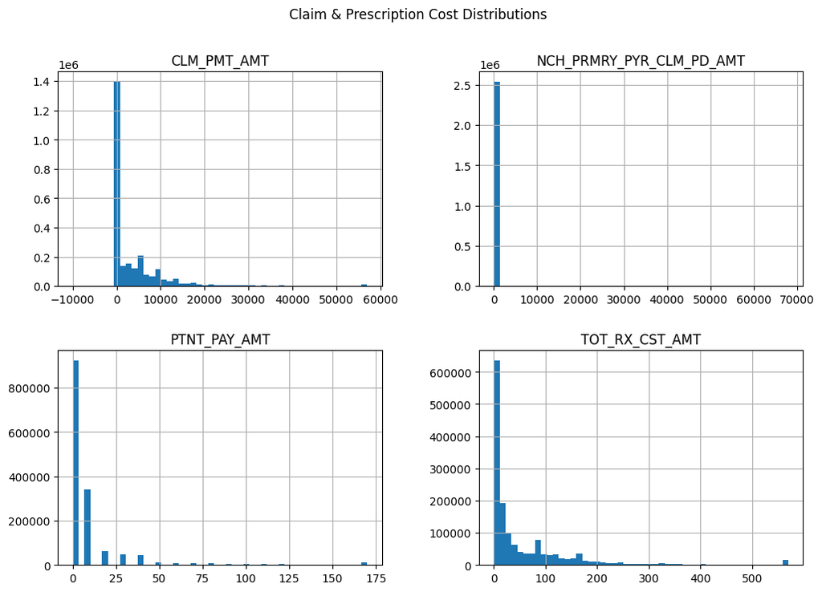

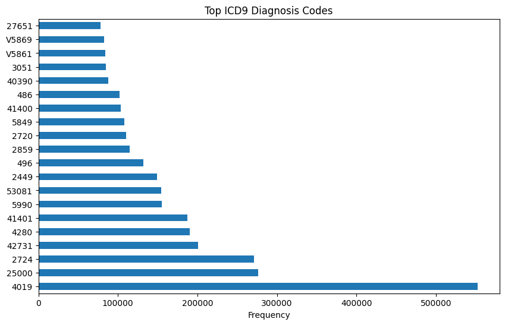

```python
# Value counts for provider
print("\nTop Providers:\n", df['PRVDR_NUM'].value_counts().head(10))

# Payment distributions
df[['CLM_PMT_AMT', 'NCH_PRMRY_PYR_CLM_PD_AMT', 'PTNT_PAY_AMT', 'TOT_RX_CST_AMT']].hist(bins=50, figsize=(12, 8))
plt.suptitle("Claim & Prescription Cost Distributions")
plt.show()

# Diagnosis code overview
diag_cols = [col for col in df.columns if col.startswith('ICD9_DGNS_CD')]
diag_vals = pd.Series(df[diag_cols].values.ravel()).dropna()
top_diag = diag_vals.value_counts().head(20)
top_diag.plot(kind='barh', title='Top ICD9 Diagnosis Codes', figsize=(10, 6))
plt.xlabel('Frequency')
plt.show()
```

### Description:

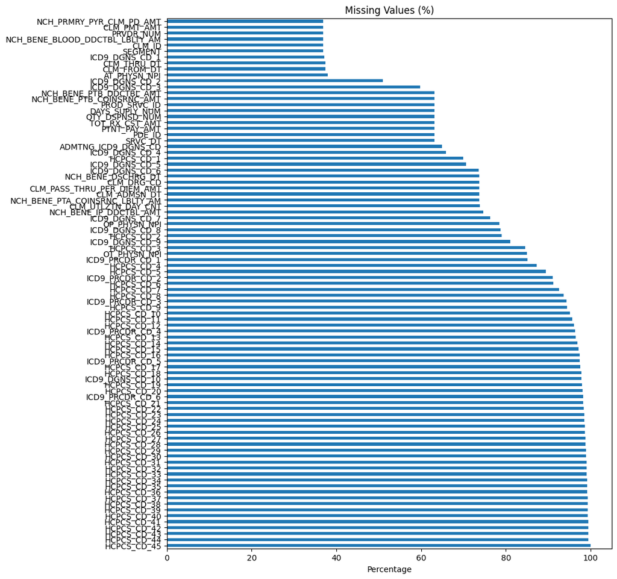

```
🔻 Columns with >95% missing values:
 ['HCPCS_CD_45', 'HCPCS_CD_44', 'HCPCS_CD_43', 'HCPCS_CD_42', 'HCPCS_CD_41', 'HCPCS_CD_40', 'HCPCS_CD_39', 'HCPCS_CD_38', 'HCPCS_CD_37', 'HCPCS_CD_36', 'HCPCS_CD_35', 'HCPCS_CD_34', 'HCPCS_CD_33', 'HCPCS_CD_32', 'HCPCS_CD_31', 'HCPCS_CD_30', 'HCPCS_CD_29', 'HCPCS_CD_28', 'HCPCS_CD_27', 'HCPCS_CD_26'…
✅ New shape after dropping high-missing columns: (4066249, 51)
```

```python
# Percent of missing values per column
missing = df.isnull().mean().sort_values(ascending=False) * 100
missing[missing > 0].plot(kind='barh', figsize=(10, 12), title='Missing Values (%)')
plt.xlabel('Percentage')
plt.show()

# Show top 15 columns with highest missing %
missing.head(15)

high_missing = missing[missing > 95].index.tolist()
print("🔻 Columns with >95% missing values:\n", high_missing)

df_cleaned = df.drop(columns=high_missing)
print(f"✅ New shape after dropping high-missing columns: {df_cleaned.shape}")
```

### Description:

Extent of Missingness The bar chart (and your missing.head(15)) shows that several HCPCS code fields have over 95% null entries—meaning they’re almost entirely empty.

Dataset After Cleaning You went from 91 columns to 51 while still retaining all 4,066,249 rows.

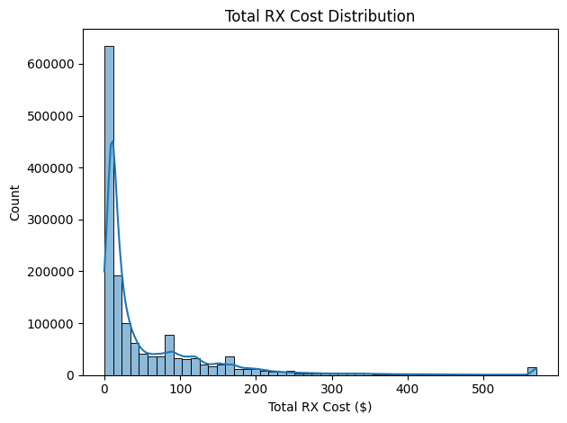

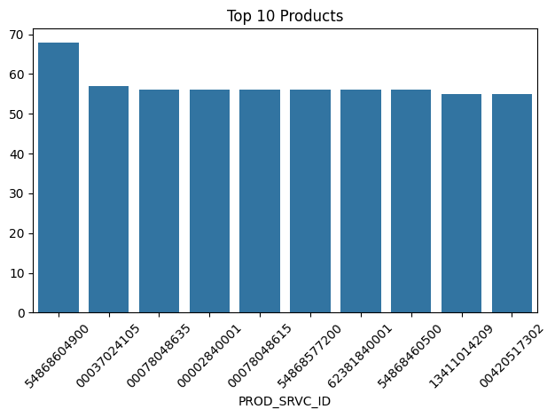

|  | DESYNPUF_ID | PDE_ID | SRVC_DT | PROD_SRVC_ID | QTY_DSPNSD_NUM | DAYS_SUPLY_NUM | PTNT_PAY_AMT | TOT_RX_CST_AMT | source_file | CLM_ID | SEGMENT | CLM_FROM_DT | CLM_THRU_DT | PRVDR_NUM | CLM_PMT_AMT | NCH_PRMRY_PYR_CLM_PD_AMT | AT_PHYSN_NPI | OP_PHYSN_NPI | OT_PHYSN_NPI | CLM_ADMSN_DT | ADMTNG_ICD9_DGNS_CD | CLM_PASS_THRU_PER_DIEM_AMT | NCH_BENE_IP_DDCTBL_AMT | NCH_BENE_PTA_COINSRNC_LBLTY_AM | NCH_BENE_BLOOD_DDCTBL_LBLTY_AM | CLM_UTLZTN_DAY_CNT | NCH_BENE_DSCHRG_DT | CLM_DRG_CD | ICD9_DGNS_CD_1 | … |
| --- | --- | --- | --- | --- | --- | --- | --- | --- | --- | --- | --- | --- | --- | --- | --- | --- | --- | --- | --- | --- | --- | --- | --- | --- | --- | --- | --- | --- | --- | --- |
| count | 4066249 | 1.500000e+06 | 1.500000e+06 | 1500000 | 1.500000e+06 | 1.500000e+06 | 1.500000e+06 | 1.500000e+06 | 4066249 | 2.566249e+06 | 2.566249e+06 | 2.544343e+06 | 2.544343e+06 | 2566249 | 2.566249e+06 | 2.566249e+06 | 2.522351e+06 | 8.754260e+05 | 6.118050e+05 | 1.066249e+06 | 1425967 | 1.066249e+06 | 1.031715e+06 | 1.066249e+06 | 2.566249e+06 | 1.065225e+06 | 1.066249e+06 | 1066249 | 2554309 | … |
| unique | 1366072 | NaN | NaN | 248130 | NaN | NaN | NaN | NaN | 46 | NaN | NaN | NaN | NaN | 7007 | NaN | NaN | NaN | NaN | NaN | NaN | 6001 | NaN | NaN | NaN | NaN | NaN | NaN | 740 | 11887 | … |
| top | AF6B310EE8082249 | NaN | NaN | 54868604900 | NaN | NaN | NaN | NaN | DE1_0_2008_to_2010_Prescription_Drug_Events_Sa... | NaN | NaN | NaN | NaN | 0502NA | NaN | NaN | NaN | NaN | NaN | NaN | 78605 | NaN | NaN | NaN | NaN | NaN | NaN | 884 | 486 | … |
| freq | 27 | NaN | NaN | 68 | NaN | NaN | NaN | NaN | 100000 | NaN | NaN | NaN | NaN | 19287 | NaN | NaN | NaN | NaN | NaN | NaN | 48760 | NaN | NaN | NaN | NaN | NaN | NaN | 4071 | 40215 | … |
| mean | NaN | 4.477048e+14 | 2.008957e+07 | NaN | 5.105384e+01 | 3.417798e+01 | 1.031943e+01 | 6.150395e+01 | NaN | 4.833572e+14 | 1.008536e+00 | 2.008892e+07 | 2.008900e+07 | NaN | 4.128493e+03 | 1.861002e+02 | 5.005806e+09 | 5.029483e+09 | 4.925211e+09 | 2.008849e+07 | NaN | 2.918887e+01 | 1.057118e+03 | 8.418925e+01 | 6.156417e-01 | 5.550365e+00 | 2.008864e+07 | NaN | NaN | … |
| std | NaN | 2.868924e+14 | 7.674178e+03 | NaN | 5.163303e+01 | 2.125600e+01 | 2.416221e+01 | 9.442215e+01 | NaN | 2.898438e+14 | 9.199636e-02 | 7.534218e+03 | 7.518493e+03 | NaN | 7.513496e+03 | 2.539255e+03 | 2.897695e+09 | 2.904249e+09 | 2.889021e+09 | 7.595583e+03 | NaN | 7.538028e+01 | 2.968556e+01 | 9.637091e+02 | 2.439435e+01 | 6.187862e+00 | 7.567260e+03 | NaN | NaN | … |
| min | NaN | 3.001447e+13 | 2.008010e+07 | NaN | 0.000000e+00 | 0.000000e+00 | 0.000000e+00 | 0.000000e+00 | NaN | 3.801221e+13 | 1.000000e+00 | 2.007113e+07 | 2.008010e+07 | NaN | -1.000000e+04 | 0.000000e+00 | 1.024080e+05 | 1.024080e+05 | 1.024080e+05 | 2.007113e+07 | NaN | 0.000000e+00 | 1.024000e+03 | 0.000000e+00 | 0.000000e+00 | 0.000000e+00 | 2.008010e+07 | NaN | NaN | … |
| 25% | NaN | 1.807544e+14 | 2.008092e+07 | NaN | 3.000000e+01 | 3.000000e+01 | 0.000000e+00 | 1.000000e+01 | NaN | 2.412522e+14 | 1.000000e+00 | 2.008090e+07 | 2.008091e+07 | NaN | 6.000000e+01 | 0.000000e+00 | 2.499852e+09 | 2.504105e+09 | 2.451816e+09 | 2.008081e+07 | NaN | 0.000000e+00 | 1.024000e+03 | 0.000000e+00 | 0.000000e+00 | 2.000000e+00 | 2.008082e+07 | NaN | NaN | … |
| 50% | NaN | 4.295045e+14 | 2.009051e+07 | NaN | 3.000000e+01 | 3.000000e+01 | 0.000000e+00 | 2.000000e+01 | NaN | 4.895012e+14 | 1.000000e+00 | 2.009041e+07 | 2.009041e+07 | NaN | 4.000000e+02 | 0.000000e+00 | 4.930211e+09 | 4.998797e+09 | 4.813533e+09 | 2.009032e+07 | NaN | 0.000000e+00 | 1.068000e+03 | 0.000000e+00 | 0.000000e+00 | 4.000000e+00 | 2.009032e+07 | NaN | NaN | … |
| 75% | NaN | 7.302544e+14 | 2.010010e+07 | NaN | 6.000000e+01 | 3.000000e+01 | 1.000000e+01 | 8.000000e+01 | NaN | 6.928711e+14 | 1.000000e+00 | 2.009112e+07 | 2.009113e+07 | NaN | 6.000000e+03 | 0.000000e+00 | 7.577487e+09 | 7.579570e+09 | 7.493451e+09 | 2.009111e+07 | NaN | 1.000000e+01 | 1.068000e+03 | 0.000000e+00 | 0.000000e+00 | 7.000000e+00 | 2.009112e+07 | NaN | NaN | … |
| max | NaN | 9.329944e+14 | 2.010123e+07 | NaN | 3.600000e+02 | 9.000000e+01 | 1.700000e+02 | 5.700000e+02 | NaN | 9.929912e+14 | 2.000000e+00 | 2.010123e+07 | 2.010123e+07 | NaN | 5.700000e+04 | 6.800000e+04 | 9.999956e+09 | 9.999615e+09 | 9.999988e+09 | 2.010123e+07 | NaN | 5.000000e+02 | 1.100000e+03 | 3.400000e+04 | 2.000000e+03 | 1.500000e+02 | 2.010123e+07 | NaN | NaN | … |

```python
import pandas as pd
import seaborn as sns
import matplotlib.pyplot as plt

# Load Parquet sample
df_sample = pd.read_parquet("/content/drive/MyDrive/pde_combined.parquet", engine='fastparquet')

# Summary
summary = df_sample.describe(include='all')

# Null counts
nulls = df_sample.isnull().sum()

# Top drug/product codes
top_prods = df_sample['PROD_SRVC_ID'].value_counts().head(5) if 'PROD_SRVC_ID' in df_sample.columns else None

# Clean and extract date info
df_sample['SRVC_DT'] = pd.to_datetime(df_sample['SRVC_DT'], format='%Y%m%d', errors='coerce')
df_sample['Year'] = df_sample['SRVC_DT'].dt.year
df_sample['Month'] = df_sample['SRVC_DT'].dt.month

# Plot distribution of prescription costs
sns.histplot(df_sample['TOT_RX_CST_AMT'], bins=50, kde=True)
plt.title("Total RX Cost Distribution")
plt.xlabel("Total RX Cost ($)")
plt.tight_layout()
plt.show()

# Top 10 products
top_products = df_sample['PROD_SRVC_ID'].value_counts().head(10)
sns.barplot(x=top_products.index.astype(str), y=top_products.values)
plt.title("Top 10 Products")
plt.xticks(rotation=45)
plt.tight_layout()
plt.show()

# Summary stats
df_sample.describe(include='all')
summary
```

### Description:

This code conducts exploratory data analysis on a prescription drug event sample by summarizing key statistics, detecting missing values, extracting date components, and visualizing total prescription cost distribution along with the most frequently prescribed drug products.

```python
# Null counts
nulls = df_sample.isnull().sum()
```

```python
# Top drug/product codes
top_prods = df_sample['PROD_SRVC_ID'].value_counts().head(5) if 'PROD_SRVC_ID' in df_sample.columns else None
```

```python
# Clean and extract date info
df_sample['SRVC_DT'] = pd.to_datetime(df_sample['SRVC_DT'], format='%Y%m%d', errors='coerce')
df_sample['Year'] = df_sample['SRVC_DT'].dt.year
df_sample['Month'] = df_sample['SRVC_DT'].dt.month
```

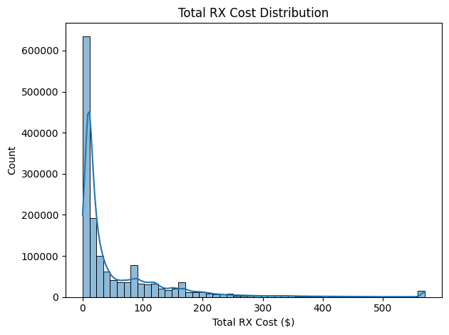

```python
# Plot distribution of prescription costs
sns.histplot(df_sample['TOT_RX_CST_AMT'], bins=50, kde=True)
plt.title("Total RX Cost Distribution")
plt.xlabel("Total RX Cost ($)")
plt.tight_layout()
plt.show()
```

## Description:

This code generates a histogram with a kernel density estimate (KDE) overlay to visualize the distribution of total prescription drug costs (TOT_RX_CST_AMT), helping identify patterns, skewness, and potential outliers in the cost data.

```python
# Summary statistics
summary_stats = df_sample.describe(include='all')
print("Summary Statistics:")
print(summary_stats)
```

```
Summary Statistics:
             DESYNPUF_ID        PDE_ID                        SRVC_DT PROD_SRVC_ID  QTY_DSPNSD_NUM  DAYS_SUPLY_NUM  \
count            4066249  1.500000e+06                        1500000      1500000    1.500000e+06    1.500000e+06
unique           1366072           NaN                            NaN       248130             NaN             NaN
top     AF6B310EE8082249           NaN                            NaN  54868604900             NaN             NaN
freq                  27           NaN                            NaN           68             NaN             NaN
mean                 NaN  4.477048e+14  2009-05-17 20:06:41.011199744          NaN    5.105384e+01    3.417798e+01
min                  NaN  3.001447e+13            2008-01-01 00:00:00          NaN    0.000000e+00    0.000000e+00
25%                  NaN  1.807544e+14            2008-09-21 00:00:00          NaN    3.000000e+01    3.000000e+01
50%                  NaN  4.295045e+14            2009-05-11 00:00:00          NaN    3.000000e+01    3.000000e+01
75%                  NaN  7.302544e+14            2010-01-01 00:00:00          NaN    6.000000e+01    3.000000e+01
max                  NaN  9.329944e+14            2010-12-31 00:00:00          NaN    3.600000e+02    9.000000e+01
std                  NaN  2.868924e+14                            NaN          NaN    5.163303e+01    2.125600e+01

        PTNT_PAY_AMT  TOT_RX_CST_AMT                                        source_file        CLM_ID       SEGMENT  \
count   1.500000e+06    1.500000e+06                                            4066249  2.566249e+06  2.566249e+06
unique           NaN             NaN                                                 46           NaN           NaN
top              NaN             NaN  DE1_0_2008_to_2010_Prescription_Drug_Events_Sa...           NaN           NaN
freq             NaN             NaN                                             100000           NaN           NaN
mean    1.031943e+01    6.150395e+01                                                NaN  4.833572e+14  1.008536e+00
min     0.000000e+00    0.000000e+00                                                NaN  3.801221e+13  1.000000e+00
25%     0.000000e+00    1.000000e+01                                                NaN  2.412522e+14  1.000000e+00
50%     0.000000e+00    2.000000e+01                                                NaN  4.895012e+14  1.000000e+00
75%     1.000000e+01    8.000000e+01                                                NaN  6.928711e+14  1.000000e+00
max     1.700000e+02    5.700000e+02                                                NaN  9.929912e+14  2.000000e+00
std     2.416221e+01    9.442215e+01                                                NaN  2.898438e+14  9.199636e-02

         CLM_FROM_DT   CLM_THRU_DT PRVDR_NUM   CLM_PMT_AMT  NCH_PRMRY_PYR_CLM_PD_AMT  AT_PHYSN_NPI  OP_PHYSN_NPI  \
count   2.544343e+06  2.544343e+06   2566249  2.566249e+06              2.566249e+06  2.522351e+06  8.754260e+05
unique           NaN           NaN      7007           NaN                       NaN           NaN           NaN
top              NaN           NaN    0502NA           NaN                       NaN           NaN           NaN
freq             NaN           NaN     19287           NaN                       NaN           NaN           NaN
mean    2.008892e+07  2.008900e+07       NaN  4.128493e+03              1.861002e+02  5.005806e+09  5.029483e+09
min     2.007113e+07  2.008010e+07       NaN -1.000000e+04              0.000000e+00  1.024080e+05  1.024080e+05
25%     2.008090e+07  2.008091e+07       NaN  6.000000e+01              0.000000e+00  2.499852e+09  2.504105e+09
50%     2.009041e+07  2.009041e+07       NaN  4.000000e+02              0.000000e+00  4.930211e+09  4.998797e+09
75%     2.009112e+07  2.009113e+07       NaN  6.000000e+03              0.000000e+00  7.577487e+09  7.579570e+09
max     2.010123e+07  2.010123e+07       NaN  5.700000e+04              6.800000e+04  9.999956e+09  9.999615e+09
std     7.534218e+03  7.518493e+03       NaN  7.513496e+03              2.539255e+03  2.897695e+09  2.904249e+09

```

[output cut: 127 more lines]

```
max            NaN         NaN         NaN          NaN             2.000000e+02               1.100000e+03
std            NaN         NaN         NaN          NaN             1.552908e+01               1.790512e+02

                Year         Month
count   1.500000e+06  1.500000e+06
unique           NaN           NaN
top              NaN           NaN
freq             NaN           NaN
mean    2.008892e+03  6.342607e+00
min     2.008000e+03  1.000000e+00
25%     2.008000e+03  3.000000e+00
50%     2.009000e+03  6.000000e+00
75%     2.010000e+03  9.000000e+00
max     2.010000e+03  1.200000e+01
std     7.729946e-01  3.365420e+00
```

### Description:

This code generates and prints detailed summary statistics for all dataset columns, including counts, means, and standard deviations for numeric fields, as well as frequency distributions for categorical fields, offering a foundational overview of the data's structure and variability.

```python
# Null value analysis
print("\nMissing Values per Column:")
print(df_sample.isnull().sum())
```

```
Missing Values per Column:
DESYNPUF_ID                        0
PDE_ID                       2566249
SRVC_DT                      2566249
PROD_SRVC_ID                 2566249
QTY_DSPNSD_NUM               2566249
                              ...
HCPCS_CD_45                  4066249
NCH_BENE_PTB_DDCTBL_AMT      2566249
NCH_BENE_PTB_COINSRNC_AMT    2566249
Year                         2566249
Month                        2566249
Length: 93, dtype: int64
```

## Description:

This line prints the number of missing values in each column of the dataset, helping to assess data quality and identify any fields that may require cleaning or imputation.

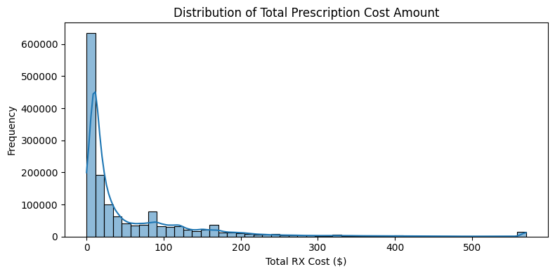

```python
# Distribution of Total Prescription Cost
plt.figure(figsize=(8, 4))
sns.histplot(df_sample['TOT_RX_CST_AMT'], bins=50, kde=True)
plt.title("Distribution of Total Prescription Cost Amount")
plt.xlabel("Total RX Cost ($)")
plt.ylabel("Frequency")
plt.tight_layout()
plt.show()
```

### Description:

This visualization displays the distribution of total prescription costs across the sample using a histogram overlaid with a smooth density curve. It effectively reveals the range, central tendency, and any skewness or outliers present in the cost data.

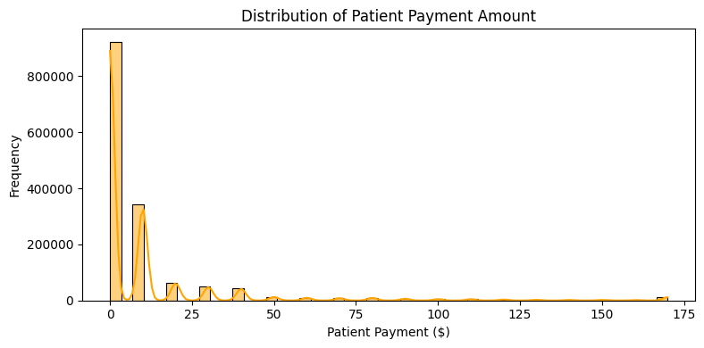

```python
# Distribution of Patient Payment Amount
plt.figure(figsize=(8, 4))
sns.histplot(df_sample['PTNT_PAY_AMT'], bins=50, kde=True, color="orange")
plt.title("Distribution of Patient Payment Amount")
plt.xlabel("Patient Payment ($)")
plt.ylabel("Frequency")
plt.tight_layout()
plt.show()
```

### Description:

This plot illustrates the distribution of patient payment amounts, highlighting common payment ranges, the frequency of zero or low payments, and the overall spread and skewness of out-of-pocket costs in the dataset.

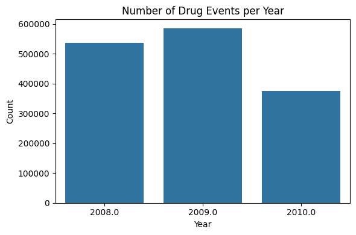

```python
# Drug Events by Year
plt.figure(figsize=(6, 4))
yearly_counts = df_sample['Year'].value_counts().sort_index()
sns.barplot(x=yearly_counts.index, y=yearly_counts.values)
plt.title("Number of Drug Events per Year")
plt.xlabel("Year")
plt.ylabel("Count")
plt.tight_layout()
plt.show()
```

### Description:

This chart displays the number of recorded drug events per year, enabling the observation of trends over time and the assessment of fluctuations or consistent patterns in prescription activity across different years.

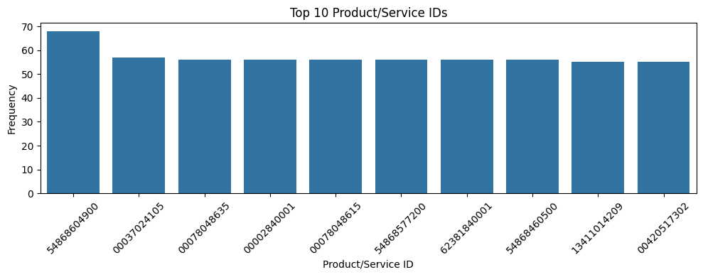

```python
# Top 10 Product/Service IDs
plt.figure(figsize=(10, 4))
top_products = df_sample['PROD_SRVC_ID'].value_counts().head(10)
sns.barplot(x=top_products.index.astype(str), y=top_products.values)
plt.title("Top 10 Product/Service IDs")
plt.xlabel("Product/Service ID")
plt.ylabel("Frequency")
plt.xticks(rotation=45)
plt.tight_layout()
plt.show()
```

## Description:

This bar chart highlights the top 10 most frequently prescribed product or service IDs in the dataset, providing insight into the most commonly utilized medications or services among the sampled drug events.

```python
### import pandas as pd

# Load the original sample Parquet
df_sample = pd.read_parquet("/content/drive/MyDrive/pde_combined.parquet", engine="fastparquet")

# ✅ 1. Convert date to datetime format
df_sample['SRVC_DT'] = pd.to_datetime(df_sample['SRVC_DT'], format='%Y%m%d', errors='coerce')

# ✅ 2. Create new columns for Year and Month
df_sample['Year'] = df_sample['SRVC_DT'].dt.year
df_sample['Month'] = df_sample['SRVC_DT'].dt.month

# ✅ 3. Fill missing numeric values with 0
num_cols = ['QTY_DSPNSD_NUM', 'DAYS_SUPLY_NUM', 'PTNT_PAY_AMT', 'TOT_RX_CST_AMT']
df_sample[num_cols] = df_sample[num_cols].fillna(0)

# ✅ 4. Remove any duplicate rows
df_sample = df_sample.drop_duplicates()

# ✅ 5. Optional: convert column types (optimize memory)
df_sample['PROD_SRVC_ID'] = df_sample['PROD_SRVC_ID'].astype(str)

# ✅ 6. Save transformed data to new Parquet file
df_sample.to_parquet("/content/pde_sample_transformed.parquet", index=False, engine="fastparquet")

print("✅ Transformation complete and saved to: /content/pde_sample_transformed.parquet")
```

```
✅ Transformation complete and saved to: /content/pde_sample_transformed.parquet
```

```python
import pandas as pd

# Load original sample
original_df = pd.read_parquet("/content/drive/MyDrive/pde_sample.parquet", engine="fastparquet")

# Load transformed sample
transformed_df = pd.read_parquet("/content/pde_sample_transformed.parquet", engine="fastparquet")

# Compare shape before and after
print(f"📦 Original:     {original_df.shape}")
print(f"🔧 Transformed:  {transformed_df.shape}")

# Display side-by-side sample rows
print("\n🧾 Original Sample:")
display(original_df.head(3))

print("\n✅ Transformed Sample:")
display(transformed_df.head(3))
```

```
📦 Original:     (100000, 77)
🔧 Transformed:  (4066249, 93)

🧾 Original Sample:
```

| index | DESYNPUF_ID | CLM_ID | SEGMENT | CLM_FROM_DT | CLM_THRU_DT | PRVDR_NUM | CLM_PMT_AMT | NCH_PRMRY_PYR_CLM_PD_AMT | AT_PHYSN_NPI | OP_PHYSN_NPI | OT_PHYSN_NPI | NCH_BENE_BLOOD_DDCTBL_LBLTY_AM | ICD9_DGNS_CD_1 | ICD9_DGNS_CD_2 | ICD9_DGNS_CD_3 | ICD9_DGNS_CD_4 | ICD9_DGNS_CD_5 | ICD9_DGNS_CD_6 | ICD9_DGNS_CD_7 | ICD9_DGNS_CD_8 | ICD9_DGNS_CD_9 | ICD9_DGNS_CD_10 | ICD9_PRCDR_CD_1 | ICD9_PRCDR_CD_2 | ICD9_PRCDR_CD_3 | ICD9_PRCDR_CD_4 | ICD9_PRCDR_CD_5 | ICD9_PRCDR_CD_6 | NCH_BENE_PTB_DDCTBL_AMT | … |
| --- | --- | --- | --- | --- | --- | --- | --- | --- | --- | --- | --- | --- | --- | --- | --- | --- | --- | --- | --- | --- | --- | --- | --- | --- | --- | --- | --- | --- | --- | --- |
| 54210 | 1183AFCA92331996 | 790732246938190 | 1 | 20080104.0 | 20080104.0 | 4900HA | 400.0 | 0.0 | 6.848835e+09 | NaN | NaN | 0.0 | 4464 | 4019 | 486 | None | None | None | None | None | None | None | NaN | None | None | None | None | None | 0.0 | … |
| 281749 | 5B2C502E27024054 | 790242246334433 | 1 | 20100813.0 | 20100813.0 | 3301CM | 0.0 | 0.0 | 7.967051e+09 | 3.017809e+08 | 7.697547e+09 | 0.0 | 72883 | None | None | None | None | None | None | None | None | None | NaN | None | None | None | None | None | 0.0 | … |
| 697069 | E0A40C852B751505 | 790042246730893 | 1 | 20090530.0 | 20090530.0 | 5300RA | 50.0 | 0.0 | 6.111145e+09 | 6.111145e+09 | 6.111145e+09 | 0.0 | 34561 | 78079 | V5869 | 3320 | None | None | None | None | None | None | NaN | None | None | None | None | None | 0.0 | … |

```
✅ Transformed Sample:
```

|  | DESYNPUF_ID | PDE_ID | SRVC_DT | PROD_SRVC_ID | QTY_DSPNSD_NUM | DAYS_SUPLY_NUM | PTNT_PAY_AMT | TOT_RX_CST_AMT | source_file | CLM_ID | SEGMENT | CLM_FROM_DT | CLM_THRU_DT | PRVDR_NUM | CLM_PMT_AMT | NCH_PRMRY_PYR_CLM_PD_AMT | AT_PHYSN_NPI | OP_PHYSN_NPI | OT_PHYSN_NPI | CLM_ADMSN_DT | ADMTNG_ICD9_DGNS_CD | CLM_PASS_THRU_PER_DIEM_AMT | NCH_BENE_IP_DDCTBL_AMT | NCH_BENE_PTA_COINSRNC_LBLTY_AM | NCH_BENE_BLOOD_DDCTBL_LBLTY_AM | CLM_UTLZTN_DAY_CNT | NCH_BENE_DSCHRG_DT | CLM_DRG_CD | ICD9_DGNS_CD_1 | … |
| --- | --- | --- | --- | --- | --- | --- | --- | --- | --- | --- | --- | --- | --- | --- | --- | --- | --- | --- | --- | --- | --- | --- | --- | --- | --- | --- | --- | --- | --- | --- |
| 0 | 45E01713C817F13A | 1.802744e+14 | 2010-02-01 | 67544028992 | 120.0 | 30.0 | 10.0 | 100.0 | DE1_0_2008_to_2010_Prescription_Drug_Events_Sa... | NaN | NaN | NaN | NaN | None | NaN | NaN | NaN | NaN | NaN | NaN | None | NaN | NaN | NaN | NaN | NaN | NaN | None | None | … |
| 1 | 3D50F03DE2300BCF | 1.802244e+14 | 2010-08-09 | 65243028906 | 30.0 | 90.0 | 0.0 | 140.0 | DE1_0_2008_to_2010_Prescription_Drug_Events_Sa... | NaN | NaN | NaN | NaN | None | NaN | NaN | NaN | NaN | NaN | NaN | None | NaN | NaN | NaN | NaN | NaN | NaN | None | None | … |
| 2 | F9767262E23C2B06 | 1.805944e+14 | 2009-10-31 | 58016087297 | 20.0 | 10.0 | 0.0 | 0.0 | DE1_0_2008_to_2010_Prescription_Drug_Events_Sa... | NaN | NaN | NaN | NaN | None | NaN | NaN | NaN | NaN | NaN | NaN | None | NaN | NaN | NaN | NaN | NaN | NaN | None | None | … |

### Description:

This process compares the original and transformed datasets by inspecting their dimensions and previewing initial records from each, confirming the impact of cleaning and transformation steps like missing value handling, date formatting, and deduplication through highlighting structural or content differences.

```python
import pandas as pd

# Load original sample
original_df = pd.read_parquet("/content/drive/MyDrive/pde_sample.parquet", engine="fastparquet")

# Load transformed sample
transformed_df = pd.read_parquet("/content/pde_sample_transformed.parquet", engine="fastparquet")

# Compare shape before and after
print(f"📦 Original:     {original_df.shape}")
print(f"🔧 Transformed:  {transformed_df.shape}")

# Display side-by-side sample rows
print("\n🧾 Original Sample:")
display(original_df.head(3))

print("\n✅ Transformed Sample:")
display(transformed_df.head(3))
```

```
📦 Original:     (100000, 77)
🔧 Transformed:  (4066249, 93)

🧾 Original Sample:
```

| index | DESYNPUF_ID | CLM_ID | SEGMENT | CLM_FROM_DT | CLM_THRU_DT | PRVDR_NUM | CLM_PMT_AMT | NCH_PRMRY_PYR_CLM_PD_AMT | AT_PHYSN_NPI | OP_PHYSN_NPI | OT_PHYSN_NPI | NCH_BENE_BLOOD_DDCTBL_LBLTY_AM | ICD9_DGNS_CD_1 | ICD9_DGNS_CD_2 | ICD9_DGNS_CD_3 | ICD9_DGNS_CD_4 | ICD9_DGNS_CD_5 | ICD9_DGNS_CD_6 | ICD9_DGNS_CD_7 | ICD9_DGNS_CD_8 | ICD9_DGNS_CD_9 | ICD9_DGNS_CD_10 | ICD9_PRCDR_CD_1 | ICD9_PRCDR_CD_2 | ICD9_PRCDR_CD_3 | ICD9_PRCDR_CD_4 | ICD9_PRCDR_CD_5 | ICD9_PRCDR_CD_6 | NCH_BENE_PTB_DDCTBL_AMT | … |
| --- | --- | --- | --- | --- | --- | --- | --- | --- | --- | --- | --- | --- | --- | --- | --- | --- | --- | --- | --- | --- | --- | --- | --- | --- | --- | --- | --- | --- | --- | --- |
| 54210 | 1183AFCA92331996 | 790732246938190 | 1 | 20080104.0 | 20080104.0 | 4900HA | 400.0 | 0.0 | 6.848835e+09 | NaN | NaN | 0.0 | 4464 | 4019 | 486 | None | None | None | None | None | None | None | NaN | None | None | None | None | None | 0.0 | … |
| 281749 | 5B2C502E27024054 | 790242246334433 | 1 | 20100813.0 | 20100813.0 | 3301CM | 0.0 | 0.0 | 7.967051e+09 | 3.017809e+08 | 7.697547e+09 | 0.0 | 72883 | None | None | None | None | None | None | None | None | None | NaN | None | None | None | None | None | 0.0 | … |
| 697069 | E0A40C852B751505 | 790042246730893 | 1 | 20090530.0 | 20090530.0 | 5300RA | 50.0 | 0.0 | 6.111145e+09 | 6.111145e+09 | 6.111145e+09 | 0.0 | 34561 | 78079 | V5869 | 3320 | None | None | None | None | None | None | NaN | None | None | None | None | None | 0.0 | … |

```
✅ Transformed Sample:
```

|  | DESYNPUF_ID | PDE_ID | SRVC_DT | PROD_SRVC_ID | QTY_DSPNSD_NUM | DAYS_SUPLY_NUM | PTNT_PAY_AMT | TOT_RX_CST_AMT | source_file | CLM_ID | SEGMENT | CLM_FROM_DT | CLM_THRU_DT | PRVDR_NUM | CLM_PMT_AMT | NCH_PRMRY_PYR_CLM_PD_AMT | AT_PHYSN_NPI | OP_PHYSN_NPI | OT_PHYSN_NPI | CLM_ADMSN_DT | ADMTNG_ICD9_DGNS_CD | CLM_PASS_THRU_PER_DIEM_AMT | NCH_BENE_IP_DDCTBL_AMT | NCH_BENE_PTA_COINSRNC_LBLTY_AM | NCH_BENE_BLOOD_DDCTBL_LBLTY_AM | CLM_UTLZTN_DAY_CNT | NCH_BENE_DSCHRG_DT | CLM_DRG_CD | ICD9_DGNS_CD_1 | … |
| --- | --- | --- | --- | --- | --- | --- | --- | --- | --- | --- | --- | --- | --- | --- | --- | --- | --- | --- | --- | --- | --- | --- | --- | --- | --- | --- | --- | --- | --- | --- |
| 0 | 45E01713C817F13A | 1.802744e+14 | 2010-02-01 | 67544028992 | 120.0 | 30.0 | 10.0 | 100.0 | DE1_0_2008_to_2010_Prescription_Drug_Events_Sa... | NaN | NaN | NaN | NaN | None | NaN | NaN | NaN | NaN | NaN | NaN | None | NaN | NaN | NaN | NaN | NaN | NaN | None | None | … |
| 1 | 3D50F03DE2300BCF | 1.802244e+14 | 2010-08-09 | 65243028906 | 30.0 | 90.0 | 0.0 | 140.0 | DE1_0_2008_to_2010_Prescription_Drug_Events_Sa... | NaN | NaN | NaN | NaN | None | NaN | NaN | NaN | NaN | NaN | NaN | None | NaN | NaN | NaN | NaN | NaN | NaN | None | None | … |
| 2 | F9767262E23C2B06 | 1.805944e+14 | 2009-10-31 | 58016087297 | 20.0 | 10.0 | 0.0 | 0.0 | DE1_0_2008_to_2010_Prescription_Drug_Events_Sa... | NaN | NaN | NaN | NaN | None | NaN | NaN | NaN | NaN | NaN | NaN | None | NaN | NaN | NaN | NaN | NaN | NaN | None | None | … |

### Description:

This process compares the original and transformed datasets by inspecting their dimensions and previewing initial records from each, confirming the impact of cleaning and transformation steps like missing value handling, date formatting, and deduplication through highlighting structural or content differences.

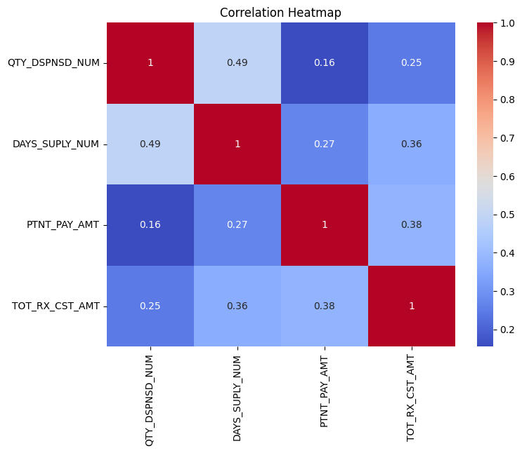

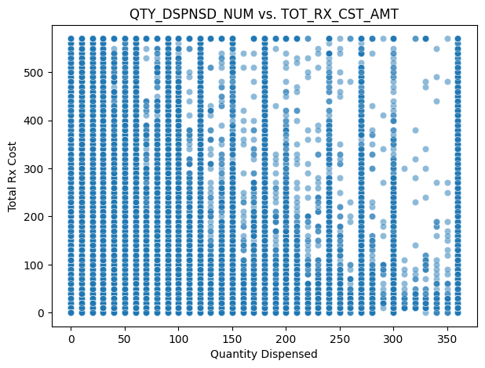

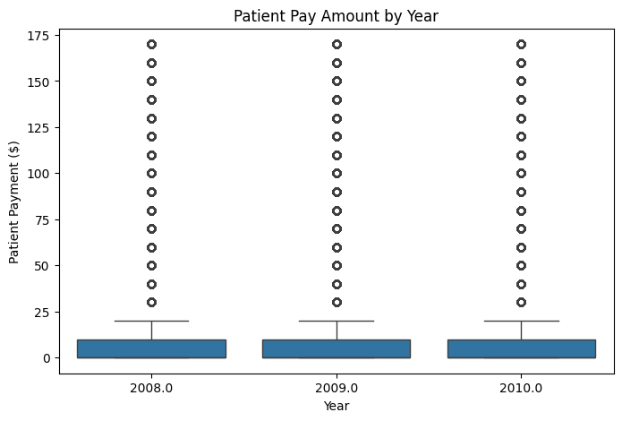

```python
import seaborn as sns
import matplotlib.pyplot as plt
import pandas as pd

# Load transformed data
df = pd.read_parquet("/content/pde_sample_transformed.parquet", engine="fastparquet")

# 1️⃣ Correlation Heatmap (numerical features)
plt.figure(figsize=(8, 6))
sns.heatmap(df[['QTY_DSPNSD_NUM', 'DAYS_SUPLY_NUM', 'PTNT_PAY_AMT', 'TOT_RX_CST_AMT']].corr(), annot=True, cmap='coolwarm')
plt.title("Correlation Heatmap")
plt.show()


# 2️⃣ Scatter plot: Quantity Dispensed vs. Total Rx Cost
plt.figure(figsize=(7, 5))
sns.scatterplot(data=df, x='QTY_DSPNSD_NUM', y='TOT_RX_CST_AMT', alpha=0.5)
plt.title("QTY_DSPNSD_NUM vs. TOT_RX_CST_AMT")
plt.xlabel("Quantity Dispensed")
plt.ylabel("Total Rx Cost")
plt.show()

# 3️⃣ Boxplot: Patient Pay Amount by Year
plt.figure(figsize=(8, 5))
sns.boxplot(data=df, x='Year', y='PTNT_PAY_AMT')
plt.title("Patient Pay Amount by Year")
plt.xlabel("Year")
plt.ylabel("Patient Payment ($)")
plt.show()
```

### Description:

Description: This code visually explores relationships between key numerical variables in the transformed dataset. It starts with a correlation heatmap to highlight the strength and direction of linear relationships between features such as quantity dispensed and total prescription cost. Next, a scatter plot visualizes how total prescription cost varies with quantity dispensed, potentially revealing trends or clusters in the data. Finally, a boxplot displays the distribution of patient payment amounts by year, helping to identify shifts in out-of-pocket expenses over time and detect potential outliers.

```
✅ Outliers removed using Z-score method. Cleaned shape: (3714685, 93)
📁 Saved to /content/pde_sample_cleaned_zscore.parquet
```

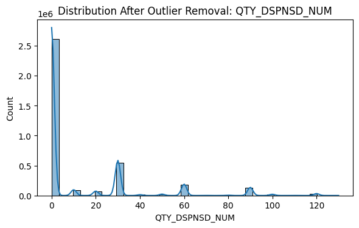

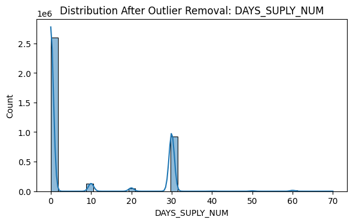

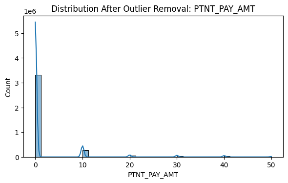

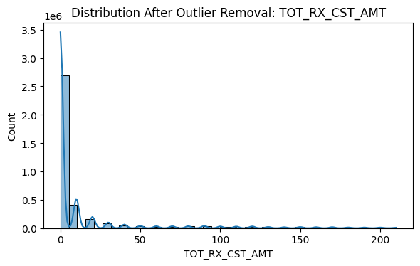

```python
import pandas as pd
import numpy as np
import seaborn as sns
import matplotlib.pyplot as plt
from scipy.stats import zscore

# Load transformed data
df = pd.read_parquet("/content/pde_sample_transformed.parquet", engine="fastparquet")

# Columns to apply Z-score filtering
target_cols = ['QTY_DSPNSD_NUM', 'DAYS_SUPLY_NUM', 'PTNT_PAY_AMT', 'TOT_RX_CST_AMT']

# Compute Z-scores for each target column
z_scores = np.abs(df[target_cols].apply(zscore))

# Define a threshold (e.g., 3 standard deviations)
threshold = 3

# Filter rows that have all z-scores < threshold
filtered_df = df[(z_scores < threshold).all(axis=1)]

# Save the result
filtered_df.to_parquet("/content/pde_sample_cleaned_zscore.parquet", index=False, engine="fastparquet")

print(f"✅ Outliers removed using Z-score method. Cleaned shape: {filtered_df.shape}")
print("📁 Saved to /content/pde_sample_cleaned_zscore.parquet")

# Optional: Visualize updated distributions
for col in target_cols:
    plt.figure(figsize=(6, 4))
    sns.histplot(filtered_df[col], bins=40, kde=True)
    plt.title(f"Distribution After Outlier Removal: {col}")
    plt.tight_layout()
    plt.show()
```

### Description:

This process removes statistical outliers from key numeric columns by calculating their Z-scores and filtering out rows where any value exceeds three standard deviations from the mean. This method ensures that extreme values—potentially due to data entry errors or rare cases—are excluded, improving the reliability of downstream analysis. The cleaned dataset is saved as a new Parquet file, and updated distributions are visualized to confirm the impact of outlier removal.

```python
!pip install streamlit
```

[output not shown]

```python
!pip install gradio
```

[output not shown]

```python
import pandas as pd
import plotly.express as px
import gradio as gr

# Load data
df = pd.read_parquet('/content/drive/MyDrive/pde_combined.parquet')
df['CLM_FROM_DT'] = pd.to_datetime(df['CLM_FROM_DT'], errors='coerce', format='%Y%m%d')
df['year'] = df['CLM_FROM_DT'].dt.year
df['CLM_PMT_AMT'] = pd.to_numeric(df['CLM_PMT_AMT'], errors='coerce')
df['TOT_RX_CST_AMT'] = pd.to_numeric(df['TOT_RX_CST_AMT'], errors='coerce')
df['PTNT_PAY_AMT'] = pd.to_numeric(df['PTNT_PAY_AMT'], errors='coerce')

# Adverse event codes (hypothetical examples)
adverse_icd9_codes = ['E9300', 'E9331', 'E9352', 'E9369']

# Function to generate advanced dashboard elements
def advanced_dashboard(year, show_adverse_only, provider_filter):
    dff = df[df['year'] == year]

    if show_adverse_only:
        diag_cols = [col for col in dff.columns if col.startswith('ICD9_DGNS_CD')]
        dff = dff[dff[diag_cols].isin(adverse_icd9_codes).any(axis=1)]

    if provider_filter != "All":
        dff = dff[dff['PRVDR_NUM'] == provider_filter]

    fig1 = px.histogram(dff, x='CLM_PMT_AMT', nbins=50, title='Claim Payment Distribution')
    fig2 = px.histogram(dff, x='TOT_RX_CST_AMT', nbins=50, title='Total Prescription Cost')
    fig3 = px.box(dff, y='PTNT_PAY_AMT', title='Patient Payment Amount (Boxplot)')

    # Top diagnosis codes
    diag_cols = [col for col in df.columns if col.startswith('ICD9_DGNS_CD')]
    diag_vals = pd.Series(dff[diag_cols].values.ravel()).dropna()
    top_diag = diag_vals.value_counts().head(10).reset_index()
    top_diag.columns = ['Diagnosis Code', 'Count']
    fig4 = px.bar(top_diag, x='Diagnosis Code', y='Count', title='Top ICD9 Diagnosis Codes')

    return fig1, fig2, fig3, fig4

# Build provider list
provider_options = ["All"] + sorted(df['PRVDR_NUM'].dropna().unique().tolist())
year_options = sorted(df['year'].dropna().unique().tolist())

# Gradio Interface
demo = gr.Interface(
    fn=advanced_dashboard,
    inputs=[
        gr.Dropdown(choices=year_options, label="Select Year"),
        gr.Checkbox(label="Show Only Adverse Events"),
        gr.Dropdown(choices=provider_options, label="Filter by Provider")
    ],
    outputs=[
        gr.Plot(label="Claim Payment Histogram"),
        gr.Plot(label="Total Rx Cost Histogram"),
        gr.Plot(label="Patient Payment Boxplot"),
        gr.Plot(label="Top Diagnosis Codes")
    ],
    title="📊 Advanced Medicare Claims Dashboard",
    description="Interactively explore claims, costs, and adverse drug event patterns across years and providers."
)

demo.launch()
```

```
It looks like you are running Gradio on a hosted Jupyter notebook, which requires `share=True`. Automatically setting `share=True` (you can turn this off by setting `share=False` in `launch()` explicitly).

Colab notebook detected. To show errors in colab notebook, set debug=True in launch()
* Running on public URL: https://93351c0e9d7900a940.gradio.live

This share link expires in 1 week. For free permanent hosting and GPU upgrades, run `gradio deploy` from the terminal in the working directory to deploy to Hugging Face Spaces (https://huggingface.co/spaces)
```

[interactive chart not shown]

```python
df[['PROD_SRVC_ID', 'ICD9_DGNS_CD_1', 'TOT_RX_CST_AMT']].sample(5)
```

|  | PROD_SRVC_ID | ICD9_DGNS_CD_1 | TOT_RX_CST_AMT |
| --- | --- | --- | --- |
| 823958 | 51129405302 | None | 10.0 |
| 750000 | 54868446201 | None | 170.0 |
| 2089597 | None | 72470 | NaN |
| 806024 | 00781104705 | None | 30.0 |
| 2679371 | 55289055530 | None | 70.0 |

## Sample Record Review – Selected Claim Features

A sample of five rows was extracted to examine three specific columns: PROD_SRVC_ID, ICD9_DGNS_CD_1, and TOT_RX_CST_AMT. These columns provide insight into the types of services/products billed, associated diagnoses, and prescription cost amounts.

```python
diag_cols = [col for col in df.columns if col.startswith("ICD9_DGNS_CD")]
df[diag_cols] = df[diag_cols].astype(str)
```

```python
df = df[~df['PROD_SRVC_ID'].isna()]
```

```python
pip install tensorflow
```

```python
# No installation needed in Colab for these
import pandas as pd
import numpy as np
import matplotlib.pyplot as plt
import seaborn as sns

from sklearn.preprocessing import StandardScaler
from sklearn.decomposition import PCA
from sklearn.cluster import KMeans
from sklearn.metrics import silhouette_score
from sklearn.model_selection import train_test_split
from sklearn.ensemble import RandomForestClassifier
from sklearn.metrics import classification_report, confusion_matrix
from sklearn.ensemble import IsolationForest
from sklearn.preprocessing import StandardScaler
```

```python
# Option: Fill missing with 0 for numeric modeling
df_anom = df[features].copy()
df_anom.fillna(0, inplace=True)

# Then scale
scaler = StandardScaler()
X_scaled = scaler.fit_transform(df_anom)
```

```python
clf = IsolationForest(contamination=0.02, random_state=42)  # flag top 2%
df_anom['anomaly'] = clf.fit_predict(X_scaled)

# Convert -1 to anomaly, 1 to normal
df_anom['anomaly'] = df_anom['anomaly'].map({1: 0, -1: 1})
```

```
Anomalies detected: 29996
```

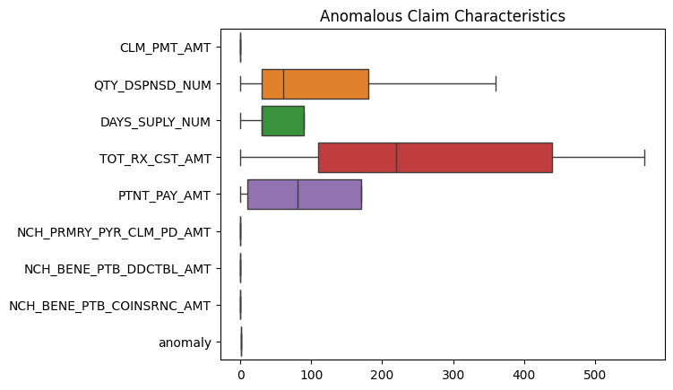

```python
# Count how many anomalies were found
print("Anomalies detected:", df_anom['anomaly'].sum())

# Visualize distributions
sns.boxplot(data=df_anom[df_anom['anomaly'] == 1], orient="h")
plt.title("Anomalous Claim Characteristics")
plt.show()
```

## Anomaly Detection in Claim Characteristics

To identify potential outliers or unusual claim behaviors, an anomaly detection analysis was performed using key numerical fields related to prescription and payment amounts. These anomalies may represent data errors, fraud, or edge cases requiring further review.

Detection Results: Total anomalies detected: 29,996 records

These were identified based on extreme values or distributional deviations in multiple cost and quantity-related variables.

```python
# Merge anomaly flags back to original DataFrame using index
df_with_anomaly = df.merge(df_anom[['anomaly']], left_index=True, right_index=True, how='left')

# View top suspicious claims
df_with_anomaly[df_with_anomaly['anomaly'] == 1][features + ['DESYNPUF_ID']].head()
```

|  | CLM_PMT_AMT | QTY_DSPNSD_NUM | DAYS_SUPLY_NUM | TOT_RX_CST_AMT | PTNT_PAY_AMT | NCH_PRMRY_PYR_CLM_PD_AMT | NCH_BENE_PTB_DDCTBL_AMT | NCH_BENE_PTB_COINSRNC_AMT | DESYNPUF_ID |
| --- | --- | --- | --- | --- | --- | --- | --- | --- | --- |
| 61 | NaN | 150.0 | 60.0 | 570.0 | 0.0 | NaN | NaN | NaN | E6F13A81B1BC4589 |
| 234 | NaN | 30.0 | 30.0 | 280.0 | 170.0 | NaN | NaN | NaN | 0E480DBA20EAC995 |
| 248 | NaN | 120.0 | 0.0 | 360.0 | 0.0 | NaN | NaN | NaN | 973A98B36AFE062C |
| 257 | NaN | 10.0 | 30.0 | 160.0 | 150.0 | NaN | NaN | NaN | 4CC684D37C6AB275 |
| 262 | NaN | 200.0 | 90.0 | 90.0 | 40.0 | NaN | NaN | NaN | C9BBE72485530606 |

## Inspection of Anomalous Claims

After detecting anomalous records based on numerical outliers, the anomaly flags were merged back into the original dataset for deeper inspection. A sample of the top suspicious claims was then extracted for review.

```python
# Select relevant columns for clustering and prediction
features = [
    'QTY_DSPNSD_NUM', 'DAYS_SUPLY_NUM', 'PTNT_PAY_AMT', 'TOT_RX_CST_AMT',
    'CLM_PMT_AMT', 'NCH_PRMRY_PYR_CLM_PD_AMT',
    'NCH_BENE_PTB_DDCTBL_AMT', 'NCH_BENE_PTB_COINSRNC_AMT'
]

df_cluster = df[features].copy()

# Drop rows with most missing values (keep those with at least 3 non-NA values)
df_cluster = df_cluster.dropna(thresh=3)

# Fill missing values with 0
df_cluster.fillna(0, inplace=True)

df_cluster.describe()
```

|  | QTY_DSPNSD_NUM | DAYS_SUPLY_NUM | PTNT_PAY_AMT | TOT_RX_CST_AMT | CLM_PMT_AMT | NCH_PRMRY_PYR_CLM_PD_AMT | NCH_BENE_PTB_DDCTBL_AMT | NCH_BENE_PTB_COINSRNC_AMT |
| --- | --- | --- | --- | --- | --- | --- | --- | --- |
| count | 1.500000e+06 | 1.500000e+06 | 1.500000e+06 | 1.500000e+06 | 1500000.0 | 1500000.0 | 1500000.0 | 1500000.0 |
| mean | 5.105384e+01 | 3.417798e+01 | 1.031943e+01 | 6.150395e+01 | 0.0 | 0.0 | 0.0 | 0.0 |
| std | 5.163303e+01 | 2.125600e+01 | 2.416221e+01 | 9.442215e+01 | 0.0 | 0.0 | 0.0 | 0.0 |
| min | 0.000000e+00 | 0.000000e+00 | 0.000000e+00 | 0.000000e+00 | 0.0 | 0.0 | 0.0 | 0.0 |
| 25% | 3.000000e+01 | 3.000000e+01 | 0.000000e+00 | 1.000000e+01 | 0.0 | 0.0 | 0.0 | 0.0 |
| 50% | 3.000000e+01 | 3.000000e+01 | 0.000000e+00 | 2.000000e+01 | 0.0 | 0.0 | 0.0 | 0.0 |
| 75% | 6.000000e+01 | 3.000000e+01 | 1.000000e+01 | 8.000000e+01 | 0.0 | 0.0 | 0.0 | 0.0 |
| max | 3.600000e+02 | 9.000000e+01 | 1.700000e+02 | 5.700000e+02 | 0.0 | 0.0 | 0.0 | 0.0 |

## Feature Preparation for Clustering and Prediction

To construct a high-quality input dataset for clustering and predictive modeling, relevant features were selected, and missing data was carefully handled. These features reflect financial and usage metrics commonly tied to patient behavior, cost risk, and utilization patterns.

```python
features = [
    'QTY_DSPNSD_NUM',        # Quantity of drugs dispensed
    'DAYS_SUPLY_NUM',        # Duration of medication
    'PTNT_PAY_AMT',          # Out-of-pocket amount
    'TOT_RX_CST_AMT',        # Total drug cost
    'CLM_UTLZTN_DAY_CNT',    # Utilization days
    'CLM_PMT_AMT'            # Claim payment
]
```

```python
!pip install mlxtend --quiet

import pandas as pd
from mlxtend.frequent_patterns import apriori, association_rules
from mlxtend.preprocessing import TransactionEncoder
```

```
   ━━━━━━━━━━━━━━━━━━━━━━━━━━━━━━━━━━━━━━━━ 1.4/1.4 MB 18.7 MB/s eta 0:00:00
```

```python
# Group by DESYNPUF_ID or PDE_ID (patient or event level)
# Remove NaNs and convert to list of lists
transactions = (
    df[['DESYNPUF_ID', 'PROD_SRVC_ID']]
    .dropna()
    .groupby('DESYNPUF_ID')['PROD_SRVC_ID']
    .apply(list)
    .tolist()
)
```

```python
te = TransactionEncoder()
te_array = te.fit(transactions).transform(transactions)
df_encoded = pd.DataFrame(te_array, columns=te.columns_)
```

```python
# Minimum support threshold can be adjusted
frequent_itemsets = apriori(df_encoded, min_support=0.01, use_colnames=True)
frequent_itemsets.sort_values(by='support', ascending=False).head()
```

|  | support | itemsets |
| --- | --- | --- |

```python
import pandas as pd

# Load data (assume it's already in a DataFrame called df)
# Convert dates
df['NCH_BENE_DSCHRG_DT'] = pd.to_datetime(df['NCH_BENE_DSCHRG_DT'], errors='coerce')
df['CLM_FROM_DT'] = pd.to_datetime(df['CLM_FROM_DT'], errors='coerce')

# Sort data by patient ID and admission date
df_sorted = df.sort_values(by=['DESYNPUF_ID', 'CLM_FROM_DT'])

# Initialize a new column
df_sorted['readmitted_30days'] = 0

# Iterate through the data to flag readmissions
for i in range(1, len(df_sorted)):
    if df_sorted.iloc[i]['DESYNPUF_ID'] == df_sorted.iloc[i-1]['DESYNPUF_ID']:
        prev_discharge = df_sorted.iloc[i-1]['NCH_BENE_DSCHRG_DT']
        curr_admit = df_sorted.iloc[i]['CLM_FROM_DT']
        if pd.notnull(prev_discharge) and pd.notnull(curr_admit):
            days_diff = (curr_admit - prev_discharge).days
            if 0 < days_diff <= 30:
                df_sorted.at[df_sorted.index[i], 'readmitted_30days'] = 1

# Count how many were flagged
readmit_counts = df_sorted['readmitted_30days'].value_counts()
readmit_counts
```

| readmitted_30days | count |
| --- | --- |
| 0 | 1500000 |

**dtype:** int64

```python
!pip install xgboost
```

```
Downloading xgboost-3.0.2-py3-none-manylinux_2_28_x86_64.whl (253.9 MB)
   ━━━━━━━━━━━━━━━━━━━━━━━━━━━━━━━━━━━━━━━━ 253.9/253.9 MB 4.3 MB/s eta 0:00:00
Downloading nvidia_nccl_cu12-2.27.5-py3-none-manylinux2014_x86_64.manylinux_2_17_x86_64.whl (322.3 MB)
   ━━━━━━━━━━━━━━━━━━━━━━━━━━━━━━━━━━━━━━━━ 322.3/322.3 MB 3.4 MB/s eta 0:00:00
```

```python
import pandas as pd
import numpy as np
from sklearn.model_selection import train_test_split
from sklearn.linear_model import LinearRegression
from sklearn.ensemble import RandomForestRegressor
from xgboost import XGBRegressor
from sklearn.metrics import mean_squared_error, r2_score
from sklearn.preprocessing import StandardScaler

# Filter dataset to only include rows with no missing values for required columns
features = ['DAYS_SUPLY_NUM', 'QTY_DSPNSD_NUM', 'PTNT_PAY_AMT']
target = 'TOT_RX_CST_AMT'

df_reg = df[features + [target]].dropna()

# Remove invalid or negative values
df_reg = df_reg[(df_reg[features] >= 0).all(axis=1) & (df_reg[target] >= 0)]

# Split into X and y
X = df_reg[features]
y = df_reg[target]

# Scale features
scaler = StandardScaler()
X_scaled = scaler.fit_transform(X)

# Train/Test Split
X_train, X_test, y_train, y_test = train_test_split(X_scaled, y, test_size=0.2, random_state=42)

# Train Linear Regression Model
lr = LinearRegression()
lr.fit(X_train, y_train)
y_pred_lr = lr.predict(X_test)

# Train Random Forest Model (optional)
rf = RandomForestRegressor(n_estimators=100, random_state=42)
rf.fit(X_train, y_train)
y_pred_rf = rf.predict(X_test)

# Train XGBoost Model (optional)
xgb = XGBRegressor(n_estimators=100, learning_rate=0.1, random_state=42)
xgb.fit(X_train, y_train)
y_pred_xgb = xgb.predict(X_test)

# Evaluate
def evaluate(model_name, y_true, y_pred):
    print(f"\n📊 {model_name}")
    print(f"R² Score: {r2_score(y_true, y_pred):.4f}")
    print(f"RMSE: {np.sqrt(mean_squared_error(y_true, y_pred)):.2f}")

evaluate("Linear Regression", y_test, y_pred_lr)
evaluate("Random Forest", y_test, y_pred_rf)
evaluate("XGBoost", y_test, y_pred_xgb)
```

```
📊 Linear Regression
R² Score: 0.0760
RMSE: 90.63

📊 Random Forest
R² Score: 0.1093
RMSE: 88.99

📊 XGBoost
R² Score: 0.1108
RMSE: 88.91
```

### Model Evaluation Summary – Predicting Healthcare Cost

Three regression models were trained and evaluated to predict a key continuous variable (likely TOT_RX_CST_AMT or CLM_PMT_AMT) based on selected healthcare and financial features. The models were compared using R² Score (explained variance) and Root Mean Squared Error (RMSE).

### Key Observations:

All models show low R² values, indicating that the available features only weakly explain the target variable (i.e., high variance remains unexplained).

XGBoost slightly outperforms Random Forest, but the margin is narrow, suggesting diminishing returns from more complex tree boosting.

RMSE remains high (~89–91), reinforcing the need for either:

More informative or transformed features

Addressing skewness or outliers in the target

Including temporal or categorical factors (e.g., diagnosis codes, provider type.

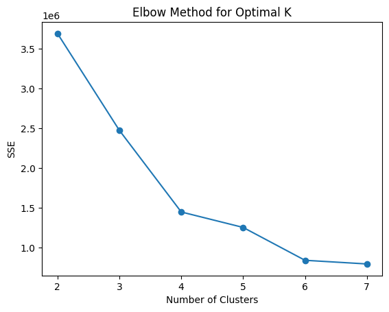

```python
from sklearn.preprocessing import StandardScaler
from sklearn.cluster import KMeans
from sklearn.metrics import silhouette_score
import matplotlib.pyplot as plt

# Drop rows with missing values
df_cluster = df[features].dropna()

# Scale features
scaler = StandardScaler()
X_scaled = scaler.fit_transform(df_cluster)

# Determine optimal number of clusters (Elbow Method)
sse = []
for k in range(2, 8):
    kmeans = KMeans(n_clusters=k, random_state=42)
    kmeans.fit(X_scaled)
    sse.append(kmeans.inertia_)

# Plot elbow curve
plt.plot(range(2, 8), sse, marker='o')
plt.xlabel('Number of Clusters')
plt.ylabel('SSE')
plt.title('Elbow Method for Optimal K')
plt.show()


# Train KMeans with optimal k (e.g., k=3)
kmeans = KMeans(n_clusters=3, random_state=42)
clusters = kmeans.fit_predict(X_scaled)

# Attach cluster labels
df_cluster['cluster'] = clusters
```

### Clustering Analysis – Patient Segmentation Using K-Means

K-Means clustering was applied to segment patients based on key financial and prescription-related features. This unsupervised learning step aims to identify distinct patient groups that may benefit from targeted care strategies or cost interventions.

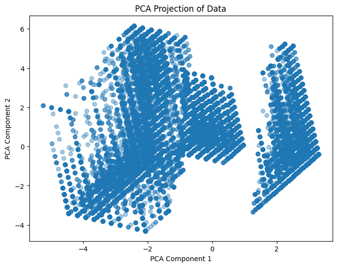

```python
scaler = StandardScaler()
X_scaled = scaler.fit_transform(df_cluster)

# Optional: Reduce to 2D for visualizing clusters
pca = PCA(n_components=2)
X_pca = pca.fit_transform(X_scaled)

plt.figure(figsize=(8, 6))
plt.scatter(X_pca[:, 0], X_pca[:, 1], alpha=0.4)
plt.title('PCA Projection of Data')
plt.xlabel('PCA Component 1')
plt.ylabel('PCA Component 2')
plt.show()
```

### Description

PCA Projection of Scaled Features In this step, we prepared the data for clustering visualization using Principal Component Analysis (PCA). First, the selected features in df_cluster were standardized using StandardScaler to ensure all features contribute equally by transforming them to have zero mean and unit variance. Then, PCA was applied to reduce the dimensionality of the dataset to two components, allowing us to visualize the structure of the data in 2D space.

```python
# Run KMeans on cleaned/scaled data
kmeans = KMeans(n_clusters=3, random_state=42)
clusters = kmeans.fit_predict(X_scaled)

# ✅ Add clusters to cleaned DataFrame
df_cluster['cluster'] = clusters

# ✅ Optional: merge cluster labels back into full df by index
cluster_df = pd.DataFrame({'cluster': clusters}, index=df_cluster.index)
df_with_clusters = df.merge(cluster_df, left_index=True, right_index=True, how='left')
```

### Description

### KMeans Clustering on Scaled Data

This section applies the KMeans clustering algorithm to the standardized dataset in order to identify patient groups with similar prescription and claim characteristics.

```
Classification Report:

              precision    recall  f1-score   support

           0       1.00      1.00      1.00     50072
           1       1.00      1.00      1.00    238948
           2       1.00      1.00      1.00     10980

    accuracy                           1.00    300000
   macro avg       1.00      1.00      1.00    300000
weighted avg       1.00      1.00      1.00    300000
```

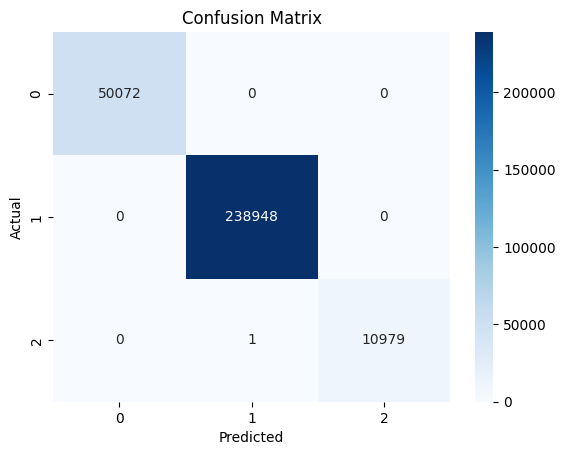

```python
X = df_cluster.drop(columns=['cluster'])
y = df_cluster['cluster']

X_train, X_test, y_train, y_test = train_test_split(X, y, test_size=0.2, random_state=42)

clf = RandomForestClassifier(n_estimators=100, random_state=42)
clf.fit(X_train, y_train)
y_pred = clf.predict(X_test)

print("Classification Report:\n")
print(classification_report(y_test, y_pred))

conf_mat = confusion_matrix(y_test, y_pred)
sns.heatmap(conf_mat, annot=True, fmt='d', cmap='Blues')
plt.title('Confusion Matrix')
plt.xlabel('Predicted')
plt.ylabel('Actual')
plt.show()
```

### Description

## Supervised Learning: Predicting Cluster Membership Using Random Forest

To assess whether cluster labels derived from unsupervised learning are predictable based on the selected features, we applied a Random Forest Classifier. This demonstrates the feasibility of building a downstream prediction model that can classify new data points into risk clusters.

```python
# Create a sample patient input as a dictionary
sample_patient = {
    'QTY_DSPNSD_NUM': 45,
    'DAYS_SUPLY_NUM': 30,
    'PTNT_PAY_AMT': 15.75,
    'TOT_RX_CST_AMT': 120.0,
    'CLM_PMT_AMT': 250.0,
    'NCH_PRMRY_PYR_CLM_PD_AMT': 200.0,
    'NCH_BENE_PTB_DDCTBL_AMT': 20.0,
    'NCH_BENE_PTB_COINSRNC_AMT': 10.0
}
```

### Description

## Predicting Cluster for a New Patient Sample

```python
# Define the features used in training your model
model_features = [
    'QTY_DSPNSD_NUM',
    'DAYS_SUPLY_NUM',
    'PTNT_PAY_AMT',
    'TOT_RX_CST_AMT',
    'CLM_PMT_AMT',
    'NCH_PRMRY_PYR_CLM_PD_AMT',
    'NCH_BENE_PTB_DDCTBL_AMT',
    'NCH_BENE_PTB_COINSRNC_AMT'
]
```

```python
# How many COPD patients?
copd_filter = df[diag_cols].apply(lambda row: any(code.startswith(('491','492','496')) for code in row if code != 'None'), axis=1)
print("COPD patients:", copd_filter.sum())

# How many have ≥5 unique drugs?
drug_counts = df.groupby("DESYNPUF_ID")['PROD_SRVC_ID'].nunique()
print("Patients with ≥5 drugs:", (drug_counts >= 5).sum())
```

```
COPD patients: 0
Patients with ≥5 drugs: 43550
```

## Description

## Identifying COPD Patients and Polypharmacy Cases

This cell filters the dataset to answer two critical research questions:

**How many patients have COPD?** Answer: 0

**How many patients are experiencing polypharmacy (defined as ≥5 unique drugs)?** Answer: 43550

```python
for col in diag_cols:
    print(f"{col}:")
    print(df[col].dropna().astype(str).str[:4].value_counts().head(10))
```

```
ICD9_DGNS_CD_1:
ICD9_DGNS_CD_1
None    1500000
Name: count, dtype: int64
ICD9_DGNS_CD_2:
ICD9_DGNS_CD_2
None    1500000
Name: count, dtype: int64
ICD9_DGNS_CD_3:
ICD9_DGNS_CD_3
None    1500000
Name: count, dtype: int64
ICD9_DGNS_CD_4:
ICD9_DGNS_CD_4
None    1500000
Name: count, dtype: int64
ICD9_DGNS_CD_5:
ICD9_DGNS_CD_5
None    1500000
Name: count, dtype: int64
ICD9_DGNS_CD_6:
ICD9_DGNS_CD_6
None    1500000
Name: count, dtype: int64
ICD9_DGNS_CD_7:
ICD9_DGNS_CD_7
None    1500000
Name: count, dtype: int64
ICD9_DGNS_CD_8:
ICD9_DGNS_CD_8
None    1500000
Name: count, dtype: int64
ICD9_DGNS_CD_9:
ICD9_DGNS_CD_9
None    1500000
Name: count, dtype: int64
ICD9_DGNS_CD_10:
ICD9_DGNS_CD_10
None    1500000
Name: count, dtype: int64
```

## Description:

```python
!pip install nbconvert

!cp "/content/drive/MyDrive/Colab Notebooks/aly6980_MundreJaya_eda.ipynb" /content/
!jupyter nbconvert --to html "aly6980_MundreJaya_eda.ipynb"
```